# Mieten in Deutschland

Worin liegen Probleme und Schwierigkeiten im deutschen Mietmarkt

# Motivation

Die Mietpreise in Deutschland spielen eine wichtige Rolle für eine Vielzahl der deutschen Bevölkerung, doch nicht alle Gemeinden sind gleichermaßen von hohen Mieten betroffen. Faktoren wie die Lage einer Stadt, das Angebot an Wohnraum, das Alter der Gebäude oder der Familienstand der Bewohner beeinflussen die Höhe der Mieten. Dies werden Sie in diesem Projekt anhand von Zensus-Daten auf Gemeindeebene für das Jahr 2022 genau untersuchen. Besonders interessant ist dabei, wie sich Mietpreise nicht nur zwischen verschiedenen Städten, sondern auch innerhalb einer Stadt unterscheiden. Sie werden feststellen, dass die Ursachen für diese Mietunterschiede komplex und vielschichtig sind. Ihre Aufgabe ist es, durch fundierte Analysen herauszuarbeiten, welche Faktoren den größten Einfluss auf die Mietentwicklung haben. Auf Basis dieser Erkenntnisse könnten Sie Handlungsempfehlungen geben, die Politik und Stadtplaner nutzen können, um die Mietpreisentwicklung besser zu steuern und Wohnraum gerechter zu gestalten.

# Datengrundlage

In diesem Projekt werden Sie mit mehreren unterschiedlichen Datensätzen arbeiten. Zum Einen werden Sie Zensusdaten aus dem Jahr 2022 zur Demografie genauer betrachten. Zum Anderen werden Sie Daten zur Wohnungszählung in deutschen Gemeinden und Städten untersuchen. Schließlich benötigen Sie die dazugehörigen Kartendaten, um die Informationen später anschaulich visualisieren zu können. Dort werden Sie die Details der Karten einlesen und darüber hinaus Zahlen zu Mieten selbstständig herunterladen und importieren.

## Einlesen

Mittlerweile wohnen knapp 54% der Menschen in Deutschland zur Miete (Stand 2022). Somit ist Deutschland das Mieterland Nummer 1 in Europa. Im Vergleich dazu haben Länder wie Frankreich (36,6%), Italien (25,7%) oder Spanien (24%) einen deutlich geringeren Anteil an Mietern. Für die Politik ist es besonders interessant zu erfahren, wie sich nun die Mieten in den unterschiedlichen Gemeinden in Deutschland verteilen und ob es Regionen gibt, wo es besonders schwer wird eine neue Wohnung zu finden. Um dies zu beleuchten, sollen Sie nun die nachfolgenden Datensätze genauer analysieren.

**1. Lesen Sie den Datensatz `Demografie_Zensus.csv` ein und speichern diesen als `demografie`.** Der Datensatz `demografie` enthält für jede Gemeinde mehrere Beobachtungen. Dies liegt daran, dass für jede Altersgruppe der Personen eine eigene Beobachtung vorliegt. Allerdings ist der Datensatz im long-Format, d.h. nicht tidy und damit nicht so, wie Sie ihn für die weitere Datenanalyse benötigen. Nun soll der Datensatz so abgeändert werden, dass jede Gemeinde nur noch eine Beobachtung darstellt. Passen Sie den Datensatz so an, dass Sie für jede `Altersgruppe` eine eigene Spalte erstellen und dort jeweils die Anzahl der Menschen, die Sie der Spalte `Anzahl pro Altersgruppe` entnehmen können, eingetragen wird.

Darüberhinaus sollen Sie nun einen weiteren Datensatz `Wohnungen_Zensus.csv` einlesen, welcher Informationen zu den einzelnen Wohnungen in den Gemeinden enthält. Speichern Sie den Datensatz in der Variable `wohnungen` ab. Vereinen Sie ihren Datensatz `demografie` mit dem Datensatz `wohnungen` und speichern Sie diesen als `zensus_daten` ab. Verwenden Sie für ihren “Join” die Variable `Regionalschlüssel`.

**Beantworten Sie anschließend die Frage, welche Art von “Join” sich in diesem Fall anbietet und warum?**

Um den Datensatz “demografie” und “wohnungen” zu vereinen, empfiehlt sich hier ein Left-Join, bei dem der Datensatz “demografie” als Basis dient. Alternativ wäre hier auch ein Right-Join möglich, wenn man die Reihenfolge der Datensätze umkehren würde. Diese Varianten sind hier sinnvoll, da wir für unseren Datensatz “zensus_daten” als Basis die verschiedenen Gemeinden brauchen. Ein Full-Join wäre hier nicht passend, da dieser alle möglichen Kombinationen aus beiden Datensätzen darstellen würde, was zu redundanten Daten führen würde. Ebenso ist auch ein Inner-Join nicht sinnvoll, da dieser Gemeinden ausschließen würde, welche beispielsweise im Datensatz “demografie” aufgeführt wurden, aber nicht im Datensatz “wohnungen” vorkommen. Da wir aber Informationen zu allen Gemeinden in Deutschland haben möchten, wäre dies kontraproduktiv.

**2. Schränken Sie nun Ihren erstellten Datensatz auf folgende Variablen ein:**

- `Name_Gemeinde`
- `Landkreis`
- `0_Insgesamt_`
- `Regionalschlüssel`
- `Alter_infr__` (01 bis 11)
- `FAMSTND_KURZ__` (1 bis 5)
- `Einwanderungserf_ausf__1`
- `Einwanderungserf_ausf__21`
- `Einwanderungserf_ausf__22`
- `Einwanderungserf_ausf__3`
- `Staatsange_kurz__1`
- `Staatsange_kurz__2`
- `BAUJAHR_10JA__` (01 bis 10)
- `WOHNFLAECHE_20S__` (01 bis 10)
- `QMMIETE`
- `LEQ`
- `ETQ`
- `FLAECHE`
- `Wohnungen_gesamt`

**Beschreiben Sie weiterhin den Datensatz. Orientieren Sie sich hierbei an folgenden Fragen und nutzen Sie das bereitgestellte README zum Datensatz:**

- Was ist eine Beobachtung?
- Wie viele Variablen hat der Datensatz?
- Welche Variablen enthält der Datensatz? Bitte beschreiben Sie diese Variablen kurz!
- Welche Städte mit mehr als 500.000 Einwohnern sind im Datensatz?
- In wie viel Prozent der Fälle haben Sie Informationen zu allen Variablen einer Beobachtung?

Im Datensatz “zensus_daten” stellt jede Zeile eine Beobachtung dar, die sich auf eine einzelne Gemeinde bezieht. Die Spaltenwerte bieten Einblick in die unterschiedlichen Merkmale der jeweiligen Gemeinde. Eine Zeile umfasst beispielsweise die Gemeinde “Adelshofen” und enthält in den Spalten Informationen wie die Einwohnerzahl oder die durchschnittliche Miete in dieser Stadt.

Der Datensatz “zensus_daten” umfasste vor der Einschränkung auf die oben genannten Variablen 73 Variablen und enthält nach der Einschränkung noch 51 Variablen. Schauen wir uns die Variablen nach der Einschränkung genauer an:

- **Name_Gemeinde:** Diese Spalte enthält die Namen der jeweiligen Stadt
- **Landkreis:** Hier wird der zur Stadt gehörende Landkreis aufgeführt
- **0_Insgesamt_:** Diese Spalte listet für jede Stadt die Gesamteinwohnerzahl auf
- **Regionalschlüssel:** Der amtliche Gemeindeschlüssel wird hier aufgelistet
- **Alter_infr__ (01 bis 11):** Hierzu gibt es elf Variablen, die die Gesamteinwohnerzahl einer Stadt auf Altersebene darstellen. Alter_infr__01 steht hierbei für die unter 3-jährigen - Alter_infr__11 steht für die über 75-jährigen. Dazwischen gibt es noch weitere genauere Unterteilungen.
- **FAMSTND_KURZ__ (1 bis 5):** Hier wird die Gesamteinwohnerzahl einer Stadt auf die Familienstände aufgeteilt. Hierbei stehen die Zahlen 1 für ledig, 2 für verheiratet, 3 für verwitwet, 4 für geschieden und 5 für ohne Angabe.
- **Einwanderungserf_ausf__1:** Diese Variable gibt die Anzahl der Personen einer Stadt ohne Einwanderungsgeschichte an
- **Einwanderungserf_ausf__21:** Diese Spalte gibt die Anzahl der Eingewanderten pro Stadt an
- **Einwanderungserf_ausf__22:** Hier wird die Anzahl der Personen angegeben, welche Nachkommen von Eingewanderten sind
- **Einwanderungserf_ausf__3:** Die Anzahl an Personen einer Stadt mit einer einseitigen Einwanderungsgeschichte
- **Staatsange_kurz__1:** Hier wird die Anzahl der Personen mit deutscher Staatsbürgerschaft aufgelistet
- **Staatsange_kurz__2:** Diese Variable zeigt die Anzahl der Personen mit ausländischer Staatsbürgerschaft, inklusive denen mit einer Staatsbürgerschaft “Staatenlos”, “Ungeklärt” und “Ohne Angabe”
- **BAUJAHR_10JA__ (01 bis 10):** Diese zehn Variablen geben die Anzahl der Wohnungen an, die in einer gewissen Zeitspanne gebaut wurden. In BAUJAHR_10JA__01 wird die Anzahl an Wohnungen erfasst, welche vor 1919 gebaut wurden - in der Variable BAUJAHR_10_JA__10 die Anzahl an Wohnungen mit Baujahr 2016 und später. Die Variablen dazwischen teilen die Zeitspanne in noch kleinere Intervalle ein.
- **WOHNFLAECHE_20S__ (01 bis 10):** In diesen zehn Variablen wird die Anzahl der Wohnungen mit einer gewissen Wohngröße angegeben. WOHNFLAECHE_20S__01 gibt dabei die Anzahl an Wohnungen an, die kleiner als 40qm sind, die weiteren Variablen umfassen dann darauf aufbauend 20qm Intervalle. Schließlich umfaast WOHNFLAECHE_20S__10 dann die Anzahl der Wohnungen, welche größer als 200qm sind.
- **QMMIETE:** Hier wird die durchschnittliche Nettokaltmiete in €/qm angegeben.
- **LEQ:** Diese Variable zeigt die Leerstandsquote (in %), also den Anteil der leerstehenden Wohnungen an allen Wohnungen
- **ETQ:** Diese Spalte zeigt die Eigentümerquote in %
- **FLAECHE:** Hier wird die durschnittliche Größe einer Wohnung in qm aufgelistet
- **Wohnungen_gesamt:** Diese Variable gibt die Anzahl aller Wohnungen in einer Stadt an

| Nummer | Städte mit mehr als 500.000 Einwohnern | Einwohneranzahl |
| --- | --- | --- |
| 1 | Berlin, Stadt | 3596999 |
| 2 | Hamburg, Freie und Hansestadt | 1808846 |
| 3 | München, Landeshauptstadt | 1478638 |
| 4 | Köln, Stadt | 1017355 |
| 5 | Frankfurt am Main, Stadt | 743268 |
| 6 | Düsseldorf, Stadt | 611258 |
| 7 | Stuttgart, Landeshauptstadt | 610458 |
| 8 | Leipzig, Stadt | 598899 |
| 9 | Dortmund, Stadt | 598246 |
| 10 | Bremen, Stadt | 575071 |
| 11 | Essen, Stadt | 571039 |
| 12 | Dresden, Stadt | 557782 |
| 13 | Nürnberg | 522554 |
| 14 | Hannover, Landeshauptstadt | 513291 |
| 15 | Duisburg, Stadt | 501415 |

Wie in der Tabelle zu sehen, gibt es in Deutschland 15 Städte mit mehr als 500.000 Einwohnern.

```
## [1] 98.58149
```

Hier wurde berechnet, in wie viel Prozent der Fälle Informationen zu allen Variablen vorliegen. Im Datensatz “zensus_daten” liegen folglich in 98.58% der Fälle Daten zu allen Variablen vor.

**3. Erstellen Sie in einem nächsten Schritt weitere Variablen, die Sie in ihrer Analyse benötigen. Diese Variablen sollen folgende Eigenschaften umfassen:**

- Je eine Variable für den Anteil kleiner, mittlerer und großer Wohnungen, wobei kleine Wohnungen (<= 59 m²), mittlere Wohnungen (60 - 159 m²) und große Wohnungen (>= 160 m²) als Anteil an den `Wohnungen_gesamt` abgebildet werden sollen.
- Je eine Variable für den Anteil neuer und alter Wohnungen. Neue Wohnungen umfassen alle Wohnungen, die ab 2010 gebaut wurden und alte Wohnungen sind alle Wohnungen vor 1950. Auch hier soll wieder der Anteil an allen Wohnungen (`Wohnungen_gesamt`) berechnet werden.
- Das Verhältnis von Personen mit deutscher Staatsangehörigkeit zu allen Bürgern der Gemeinde einschliesslich Personen mit ausländischer Staatsangehörigkeit und Personen mit dem Status “staatenlos”, “ungeklärt” und “ohne Angabe” über `Staatsange_kurz__1` und `Staatsange_kurz__2`. Hier soll der Anteil deutscher Bürger im Verhältnis zu allen Bürgern der Gemeinde bestimmt werden.

*Hinweis:* Runden Sie die Werte für die neu erstellte Variable sinnvoll!

**4. Um Karten wie bspw. in der Case Study zu erstellen, benötigen Sie Kartendaten in Form von Shapefiles (Endung .shp). In einer späteren Analyse sollen Sie die einzelnen Städte, bzw. deren Bezirke visualisieren. Hierzu müssen Sie zuerst die nötigen Shape-Files einlesen und Details zu den einzelnen Bezirken herunterladen. Sie sollen Analysen auf Basis von 1km Gitterdaten durchführen. Deshalb sollten Sie sich [diese Geogitter-Daten für die Nettokaltmieten vom statistischen Bundesamt herunterladen](https://www.zensus2022.de/static/Zensus_Veroeffentlichung/Zensus2022_Durchschn_Nettokaltmiete.zip). Speichern Sie die zip-Datei im Ordner `Daten` ab. Weiterhin sollen Sie [die Geogitter-Daten für die Leerstandsquoten herunterladen](https://www.zensus2022.de/static/Zensus_Veroeffentlichung/Marktaktive_Leerstandsquote_in_Gitterzellen.zip). Speichern Sie auch diese im Ordner `Daten` ab und lesen Sie anschließend die .csv-Dateien für Nettokaltmiete und Leerstandsquote (für das 1km-Gitter) ein.** **Weiterhin benötigen Sie die Karteninformationen für die Visualisierung der Daten. Diese befinden sich in der Datei `Shapefile_Zensus.shp`. Lesen Sie diese mit Hilfe von `st_read()` ein und speichern Sie als `shape_file` ab.** **Benennen Sie die Variablen in `shape_file` folgendermaßen um:**

- gemndnm = Name_Gemeinde
- x_mp_1k = x_mp_1km
- y_mp_1k = y_mp_1km
- gttr1km = gitter1km

Joinen Sie nun noch die beiden Dataframes zu Miete und Leerstandsquote zu `shape_file` hinzu. Verwenden Sie `y_mp_1km` und `x_mp_1km` als Joinvariable.

*Hinweis:* Im ersten Teil der Case-Study wird eine ZIP-Datei in R entpackt. Gehen Sie hier gleich vor!

# Konsistenzcheck

Nun haben Sie alle Daten zusammen, die Sie für die Analyse der Mieten in Deutschland für das Jahr 2022 benötigen. Somit können Sie nun beginnen, die ersten Analysen zu tätigen!

**5. Im Datensatz `zensus_daten`, welchen Sie zuvor eingelesen, aufgearbeitet und zusammengefügt haben, befinden sich einige große deutsche Städte. Sie möchten nun gerne die Daten, welche Sie dort aufbereitet haben, verifizieren. Dafür sollten Sie sich eine externe Quelle suchen, auf deren Basis Sie die Gesamtbevölkerung der unten aufgeführten großen Städte in Deutschland mit denen aus dem Datensatz vergleichen. Die Bevölkerungszahlen in ihrem Datensatz stammen aus dem Jahr 2022.**

Erstellen Sie eine Tabelle mit allen nachfolgenden Städten aus dem Datensatz und deren Einwohnern. Achten Sie auf eine schöne Darstellung ihrer Tabelle mittels der Pakete `kableExtra` oder `gt`.

Im Detail sollen folgende Städte in der Tabelle genauer betrachtet werden:

- “Berlin, Stadt”, “Hamburg, Freie und Hansestadt”, “München, Landeshauptstadt”, “Köln, Stadt”, “Frankfurt am Main, Stadt”, “Stuttgart, Landeshauptstadt”, “Düsseldorf, Stadt”, “Leipzig, Stadt”, “Augsburg”, “Ingolstadt”, “Ulm, Universitätsstadt”, “Reutlingen, Stadt”

Sind die Anzahl der Einwohner in ihren Daten korrekt? Nutzen Sie eine externe Datenquelle (bitte benennen und in ihrer Antwort verlinken) und führen Sie einen kurzen Konsistenzcheck durch.

| Name der Gemeinde | Einwohnerzahl lt. Datensatz | Einwohnerzahl lt. Eurostat | Differenz | Differenz in % |
| --- | --- | --- | --- | --- |
| Hamburg, Freie und Hansestadt | 1808846 | 1853935 | -45089 | -2.46 |
| Düsseldorf, Stadt | 611258 | 619477 | -8219 | -1.34 |
| Köln, Stadt | 1017355 | 1073096 | -55741 | -5.33 |
| Frankfurt am Main, Stadt | 743268 | 759224 | -15956 | -2.12 |
| Stuttgart, Landeshauptstadt | 610458 | 626275 | -15817 | -2.56 |
| Reutlingen, Stadt | 116925 | 288158 | -171233 | -84.54 |
| Ulm, Universitätsstadt | 127116 | 126949 | 167 | 0.13 |
| Ingolstadt | 136468 | 138016 | -1548 | -1.13 |
| München, Landeshauptstadt | 1478638 | 1487708 | -9070 | -0.61 |
| Augsburg | 294647 | 296478 | -1831 | -0.62 |
| Berlin, Stadt | 3596999 | 3677472 | -80473 | -2.21 |
| Leipzig, Stadt | 598899 | 601866 | -2967 | -0.49 |

Um zu überprüfen, ob die Anzahl der Einwohner korrekt erfasst wurden, wurden hier die Daten von Eurostat (https://ec.europa.eu/eurostat/de/) verwendet. Es fällt auf, dass es bei allen Städten Differenzen zwischen dem Statistischen Bundesamt und Eurostat gibt. Um diese Differenzen besser verstehen und interpretieren zu können, wurde außerdem noch der prozentuale Unterschied zwischen den Einwohnerzahlen berechnet. Es lässt sich feststellen, dass diese Differenzen - mit der Ausnahme Reutlingen - maximal 5,33% betragen. Bei Reutlingen lässt sich eine Differenz von über 84% feststellen. Dies liegt hier allerdings daran, dass Eurostat keine Daten über die Stadt Reutlingen, sondern über den Landkreis Reutlingen vorliegen. Bei Betrachtung des Statistischen Jahrbuchs 2022 der Stadt Reutlingen findet man hier als offizielle Einwohnerzahl im Jahr 2022 116.471. Hier lässt sich somit eine Differenz von <1% im Vergleich zur Einwohnerzahl im Datensatz feststellen.

Differenzen von maximal 5,33% sind ein guter Indikator für konsistente Daten. Gewisse Differenzen können immer durch die Verwendung eines unterschiedlichen Stichtages oder unterschiedlicher Methoden zur Erfassung von Einwohnerzahlen auftreten. Die verwendeten Einwohnerzahlen können daher als korrekt betrachtet werden.

# Deskriptive Analysen

**6. Schauen Sie sich in einem nächsten Schritt an, wie die Variablen im Datensatz `zensus_daten` über alle Gemeinden und Städte hinweg verteilt sind. Konkret sollten Sie eine Tabelle erstellen, welche Informationen zu folgenden Variablen enthält:**

- verschiedene Baujahre der Wohnungen
- durchschnittlicher Quadratmeterpreis
- Leerstandsquote
- Eigentümerquote
- durchschnittliche Wohnfläche
- Anteil kleiner, mittlerer und großer Wohnungen
- Einwohner

Berechnen Sie zu jeder Variablen den Mittelwert, den Median, das Minimum, das Maximum, die Standardabweichung, sowie das 25%- und das 75%- Quantil bezogen auf alle Gemeinden. Bei den Variablen Leerstandsquote, Eigentümerquote, durchschnittliche Wohnfläche, durchschnittlicher Quadratmeterpreis und Anteil kleiner, mittlerer und großer Wohnungen soll der Mittelwert als gewichteter Mittelwert nach der absoluten Anzahl an Wohnungen berechnet werden. Heben Sie die Variablen in ihrer Tabelle entsprechend hervor, bei denen sie den gewichteten Mittelwert bestimmt haben.

Beschreiben und interpretieren Sie Ihre Tabelle. Begründen Sie auch, warum es bei den genannten Variablen sinnvoll ist, den nach Anzahl der Wohnungen gewichteten Mittelwert zu verwenden. Würde es ihrer Ansicht nach Sinn machen, statt nach Wohnungen nach Einwohnern zu gewichten? Begründen Sie auch, bei welchen Variablen eine Betrachtung der Mittelwerte, Standardabweichungen und Quantile ihrer Ansicht nach als sinnvoll erscheint. Wo ist dies weniger gut geeignet? Bei welchen Variablen gibt es Auffälligkeiten? Gibt es Ausreißer nach oben oder unten?

Achten Sie auf eine schöne Darstellung ihrer Tabelle mittels der Pakete `kableExtra` oder `gt`!

*Hinweis 1:* Wenn bei den Variablen Wohnungen_klein, Wohnungen_mittel und Wohnungen_groß Werte mit `NaN` oder `Inf` auftauchen, so ersetzen Sie diese durch `NAs`.

*Hinweis 2:* Die Anzahl der Wohnungen nach Alters- bzw. Baujahrsgruppen können den Variablen entnommen werden, welche mit `BAUJAHR_10JA__` beginnen.

| Variable | Mittelwert | Median | Minimum | Maximum | Standardabweichung | Quantil25 | Quantil75 |
| --- | --- | --- | --- | --- | --- | --- | --- |
| Baujahr vor 1919 | 527.59 | 111.00 | 0.00 | 520700.00 | 5692.47 | 50.00 | 316.00 |
| Baujahr 1919-1949 | 410.88 | 69.00 | 0.00 | 281150.00 | 3526.98 | 28.00 | 221.00 |
| Baujahr 1950-1959 | 458.39 | 60.00 | 0.00 | 193475.00 | 3943.25 | 20.00 | 198.00 |
| Baujahr 1960-1969 | 608.00 | 94.00 | 0.00 | 261728.00 | 4351.18 | 30.00 | 337.50 |
| Baujahr 1970-1979 | 579.82 | 113.00 | 0.00 | 239857.00 | 3426.96 | 33.00 | 388.50 |
| Baujahr 1980-1989 | 395.81 | 91.00 | 0.00 | 223683.00 | 2676.07 | 29.00 | 295.00 |
| Baujahr 1990-1999 | 479.42 | 124.00 | 0.00 | 141456.00 | 2131.73 | 39.00 | 407.00 |
| Baujahr 2000-2009 | 251.93 | 69.00 | 0.00 | 57008.00 | 1114.23 | 23.00 | 204.00 |
| Baujahr 2010-2015 | 129.78 | 26.00 | 0.00 | 45389.00 | 828.19 | 8.00 | 88.00 |
| Baujahr 2016 und später | 155.93 | 33.00 | 0.00 | 80878.00 | 1101.49 | 9.00 | 115.00 |
| Quadratmetermiete | 7.00 | 5.53 | 0.00 | 13.84 | 1.38 | 4.82 | 6.46 |
| Leerstandsquote | 4.34 | 4.74 | 0.00 | 50.00 | 3.11 | 3.45 | 6.58 |
| Eigentümerquote | 44.36 | 68.77 | 13.49 | 100.00 | 12.72 | 60.22 | 76.11 |
| Fläche | 94.32 | 116.20 | 64.92 | 239.54 | 15.41 | 104.98 | 125.11 |
| Anteil kleine Wohnungen | 23.17 | 8.86 | 0.00 | 59.05 | 8.04 | 5.73 | 14.26 |
| Anteil mittlere Wohnungen | 67.72 | 72.98 | 0.00 | 100.00 | 6.10 | 69.21 | 75.98 |
| Anteil große Wohnungen | 9.12 | 16.32 | 0.00 | 100.00 | 7.56 | 11.07 | 21.37 |
| Einwohner gesamt | 7668.39 | 1797.00 | 9.00 | 3596999.00 | 49519.18 | 655.25 | 5505.00 |

Bitte beachten:  
Bei grün hinterlegten Zeilen wurde der gewichtete Mittelwert berechnet

Bei den grün hinterlegten Variablen wurde der Mittelwert als gewichteter Mittelwert nach der absoluten Anzahl an Wohnungen berechnet. Wenn bei diesen Variablen der normale Mittelwert berechnet worden wäre, könnten kleine Gemeinden, die beispielsweise eine sehr hohe oder auch sehr niedrige Leerstandsquote haben, den Mittelwert unverhältnismäßig beeinflussen. Da jede Gemeinde gleich stark gewichtet wird, würde dies zu einer Verzerrung der Daten führen. Durch die Berechnung des gewichteten Mittelwerts nach der absoluten Anzahl an Wohnungen wird diese verzerrte Darstellung verhindert, da nun Gemeinden mit vielen Wohnungen die Variablen stärker beeinflussen, als Gemeinden mit weniger Wohnungen.

Ob eine Gewichtung nach der Einwohnerzahl sinnvoll wäre, hängt von den Variablen ab und auch davon, welche Aussagen man über die Daten treffen möchte. Wenn man Aussagen über die Verteilung der Bevölkerung auf kleine, mittlere und große Wohnungen treffen möchte, wäre eine Gewichtung nach Einwohnern sinnvoll, da man so die prozentuale Verteilung der Bevölkerung auf die Wohnungstypen aufzeigen könnte.

Für die Quadratmetermiete ist eine solche Gewichtung nicht sinnvoll, da sie eine Eigenschaft von Wohnungen beschreibt und nicht direkt von Menschen. Eine Gewichtung nach der Anzahl der Wohnungen ist daher naheliegender und vermeidet Verzerrungen durch unterschiedliche Einwohnerzahlen. Bei der Leerstandsquote ist die Gewichtung nach Einwohnerzahlen bedingt sinnvoll, jedoch ist eine Gewichtung nach der Anzahl der Wohnungen vorzuziehen. Die Leerstandsquote bezieht sich direkt auf den Wohnungsbestand, nicht auf die Bevölkerung, sodass eine Gewichtung nach Wohnungen die Verhältnisse besser abbildet und mögliche Verzerrungen minimiert.

Für Variablen wie Leerstandsquote, Eigentümerquote, durchschnittliche Wohnfläche, durchschnittlicher Quadratmeterpreis und den Anteil kleiner, mittlerer und großer Wohnungen ist somit ein gewichteter Mittelwert besonders sinnvoll, da er verzerrende Einflüsse kleiner Gemeinden mit wenigen Wohnungen ausgleicht. Indem wir die mittleren Werte auf Basis der Wohnungsanzahl ermitteln, erhalten wir eine repräsentativere Übersicht, die die tatsächliche Wohnsituation besser widerspiegelt.

Als nächstes schauen wir uns an, bei welchen Variablen eine Betrachtung des Mittelwerts, der Standardabweichung sowie der Quantile sinnvoll ist und bei welchen dies eher nicht sinnvoll scheint.

In der Tabelle lassen sich auch noch einige weitere Auffälligkeiten erkennen. Der Tabelle kann man entnehmen, dass es auch Gemeinden gibt, in welchen es keine einzige große Wohnung, oder keine einzige mittlere Wohnung oder keine einige kleine Wohnung gibt. Ebenso gibt es wieder Gemeinden, in welchen es nur große oder nur mittlere Wohnungen gibt. Verwunderlich ist auch der kleinste Wert der Nettokaltmiete, welcher bei 0€ pro qm liegt. Dies lässt sich allerdings darauf zurückführen, dass es auch Gemeinden mit einer Eigentumsquote von 100% gibt und somit keine Miete gezahlt werden muss. Auffällig sind auch Ausreißer bei den Einwohnerzahlen. So leben im Durchschnitt in einer Gemeinde 7668,39 Einwohner - aber es gibt auch eine Stadt mit 3.596.999 Einwohnern. Ausreißer lassen sich auch bei der Anzahl der Wohnungen pro Baujahrsgruppe erkennen. Das Maximum weicht hier immer beachtlich vom Mittelwert oder Median ab. Der Median für die Anzahl der Wohnungen mit Baujahr vor 1919 liegt bei 111, das Maximum liegt wiederum bei 520.700. Diese Verteilungen zeigen, dass es in Deutschland viele Kleinstädte gibt und nur wenige Großstädte, die allerdings die statistischen Maße teils stark beeinflussen.

**7. Die Verteilung des Alters der Wohnungen scheint bereits ein Faktor zu sein, der sich auf den Mietpreis auswirken kann, da doch deutlich weniger Wohnungen ab den 2000er Jahren gebaut wurden. Nun sollen Sie etwas tiefer in ihren Datensatz eintauchen und weitere Faktoren analysieren, die sich zum einen zwischen Städten und Gemeinden unterscheiden und darüberhinaus herausfinden, ob diese Faktoren einen Einfluss auf den Mietpreis haben:**

Erstellen Sie 4 Punktdiagramme in denen Sie

- die durchschnittliche Fläche je Wohnung,
- die Leerstandsquote je Gemeinde,
- Anteil alter Wohnungen je Gemeinde,
- Anteil neuer Wohnungen je Gemeinde,

auf der x-Achse abtragen und auf der y-Achse jeweils die durchschnittliche Nettokaltmiete pro Quadratmeter. Verwenden Sie hier nun alle Gemeinden im Datensatz, um ein Gesamtbild zu erhalten und ordnen Sie die 4 Diagramme so an, dass ein Vergleich zwischen den Schaubildern schnell und einfach möglich ist. Beschreiben und interpretieren Sie die Diagramme. Gehen Sie hierbei insbesondere auf folgende Fragen ein:

- Welche Variablen scheinen besonders stark mit dem Mietpreis korreliert zu sein?
- Was könnte die Zusammenhänge erklären?

*Hinweis:* Achten Sie darauf das bei nebeneinander angeordneten Grafiken die y-Achse gleich sein sollte.

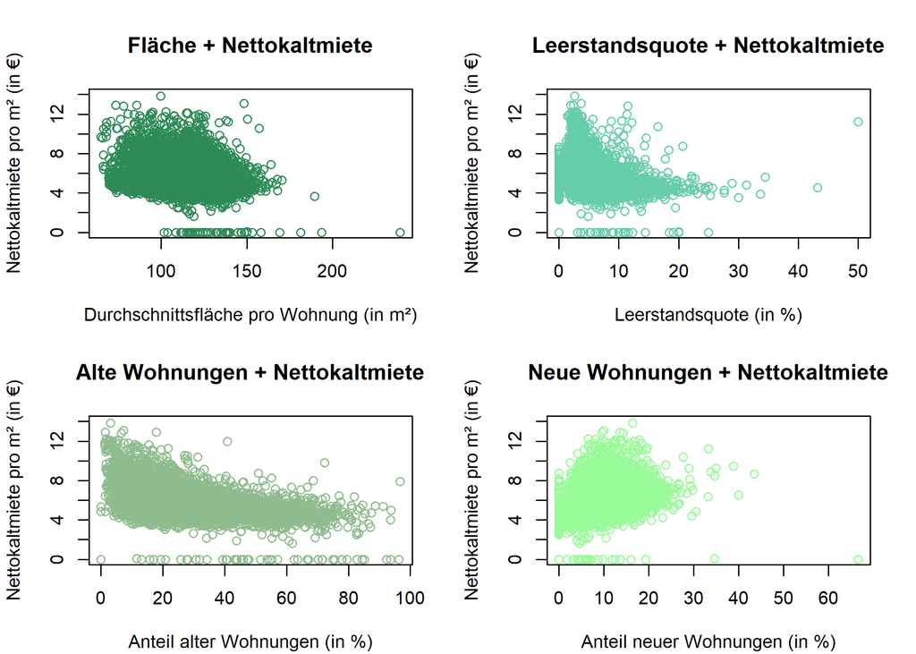

Weiterhin wäre es von Interesse in die einzelnen Großstädte Deutschlands genauer hineinzuschauen, um dort auf Besonderheiten im Wohnmarkt einzugehen. Im ersten Schritt sollen Sie Eigenschaften in Bezug auf die Wohnungen genauer untersucht werden, um zu verstehen, welche Faktoren den Mietpreis innerhalb der urbanen Räume beeinflussen könnten. Anschließend wäre es von Interesse, auch die demografischen Merkmale der Mieterinnen und Mieter in den Blick zu nehmen. Dabei stellt sich die Frage, ob und in welchem Maße diese Einfluss auf die Mietpreise und deren Struktur nehmen.

In der vorherigen Aufgabe wurden Zusammenhänge zwischen dem Alter von Wohnungen und dem Mietpreis auf Gemeindeebene untersucht. Nun soll der Fokus darauf liegen, wie sich die Wohnungen in größeren Städten hinsichtlich ihres Alters verteilen.

**8. Erstellen Sie ein Balkendiagramm für alle nachfolgenden Städte: `Stuttgart, Landeshauptstadt`, `Ulm, Universitätsstadt`, `Düsseldorf, Stadt`, `Berlin, Stadt`. Betrachten Sie dabei, wie das Alter der Wohnungen zwischen den Städten variiert. Sie sollen analysieren, wie groß der Anteil der Wohnungen abhängig nach den jeweiligen Baujahrsgruppen in den Städten ist. Tragen Sie in ihrem Balkendiagramm den *Anteil der Wohnungen nach den Baujahren* (auf der y-Achse) gegeben der *Baujahre für jede Stadt* (auf der x-Achse) ab.**

Beschreiben und interpretieren Sie die Grafik. Haben Sie diese Unterschiede erwartet? Begründen Sie warum oder warum nicht.

*Hinweis:* Denken Sie daran, dass Faktorvariablen in ggplot hilfreich sein können.

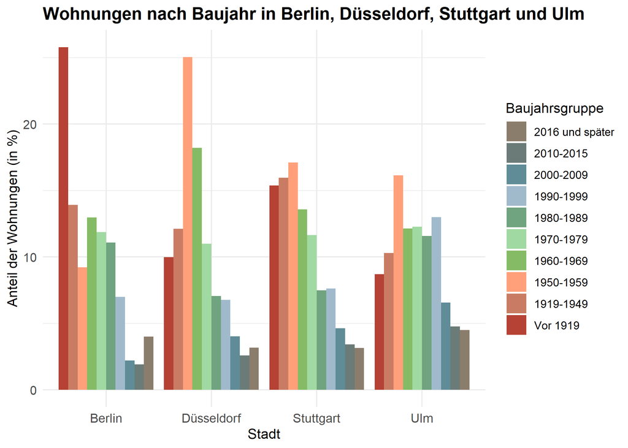

Dieses Diagramm visualisiert den Anteil der Wohnungen in Stuttgart, Ulm, Düsseldorf und Berlin, unterteilt nach den verschiedenen Baujahrsgruppen. Bereits auf den ersten Blick sieht man schnell, dass in allen vier Städten der Anteil der Wohnungen, die in den 2000er Jahren errichtet wurden, erheblich geringer ist im Vergleich zu denen aus den frühen und mittleren Jahrzehnten des 20. Jahrhunderts.

Diese Verteilung, bei der ältere Wohnungen dominieren, ist kaum überraschend. In großen Städten wurden in der ersten Hälfte und Mitte des 20. Jahrhunderts umfangreiche Bauprojekte durchgeführt, um den dringend benötigten Wohnraum für die stetig wachsende Bevölkerung zu schaffen. Anstatt die älteren Gebäude abzureißen, wurden viele dieser Bauten im Laufe der Zeit modernisiert und renoviert, sodass sie bis heute Bestand haben. Hinzu kommt die begrenzte Verfügbarkeit von Bauland in Ballungsgebieten, die naturgemäß die Zahl der Neubauten einschränkt. Zudem haben die stetig steigenden Baukosten dazu geführt, dass der Anreiz, neue Wohnungen zu errichten, gesunken ist, während viele Menschen die Option vorziehen, bestehende Wohnungen zu beziehen und zu renovieren.

**9. Wie in der vorherigen Aufgabe zu sehen war, unterscheidet sich die Situation in Städten in Bezug auf die jeweiligen Baujahre der Wohnungen deutlich. Es wäre noch spannend zu sehen, ob auch das Alter der Bewohner, die Familienstände, oder die Einwanderungshistorie der Bewohner mit unterschiedlichen Mietpreisen assoziiert sind.** **Hier sollen Sie in einem ersten generellen Schritt ein paar demografische Faktoren einbeziehen, inwiefern diese eine Auswirkung haben.** **Betrachten Sie folgende Eigenschaften genauer:**

- Familienstand
- Alter der Bewohner
- Einwanderungsgeschichte

Erstellen Sie eine oder mehrere passende Diagramme oder Grafiken für die in Aufgabe 8 aufgeführten Städte.

Beschreiben und interpretieren Sie diese. Haben Sie diese Unterschiede erwartet? Begründen Sie warum oder warum nicht. Wo gibt es Ihrer Ansicht nach besondere Auffälligkeiten? Warum kann es bei der unterschiedlichen Einteilung der Altersgruppen zu Problemen kommen? Was wären Möglichkeiten, um etwaige Probleme zu vermeiden?

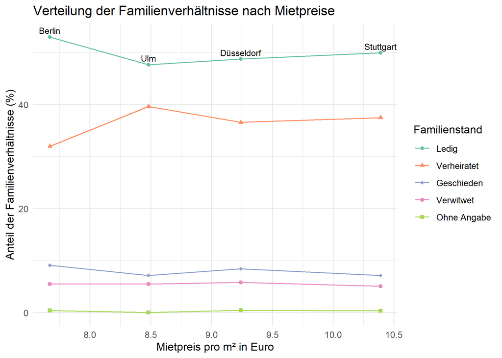

Die Grafik zeigt die Verteilung der Familienverhältnisse in Relation zu den Mietpreisen in Berlin, Ulm, Düsseldorf und Stuttgart. Dabei repräsentieren die Punkte untereinander jeweils eine der genannten Städte. In Berlin beispielsweise sind knapp über 50 % der Bevölkerung ledig, etwa 30 % verheiratet, rund 10 % geschieden, circa 6 % verwitwet, und nur ein sehr geringer Anteil macht keine Angabe. Außerdem ist der durchschnittliche Mietpreis pro Quadratmeter in Berlin der günstigste unter den vier Städten, während Stuttgart die höchsten Mietpreise aufweist.

Ausgehend von diesen Daten wird untersucht, ob ein Zusammenhang zwischen dem Familienstand und den Mietpreisen besteht. Auffällig ist, dass die prozentualen Anteile der Geschiedenen, Verwitweten und Personen ohne Angabe in allen vier Städten nahezu identisch sind, obwohl sich die Mietpreise deutlich unterscheiden. Ähnlich verhält es sich bei Verheirateten und Ledigen: Die Unterschiede zwischen den Städten betragen hier weniger als 10 Prozentpunkte, was es erschwert, eine klare Korrelation zu erkennen.

Interessant ist jedoch die Verteilung in Berlin: Im Vergleich zu den anderen drei Städten sind dort signifikant mehr Menschen ledig und weniger verheiratet, jeweils mit einem Unterschied von etwa 5 Prozentpunkten. Diese Abweichung könnte auf besondere soziale oder wirtschaftliche Faktoren hinweisen, die in Berlin eine Rolle spielen.

Um mögliche Zusammenhänge genauer zu analysieren, könnte es sinnvoll sein, die Datenbasis zu erweitern und weitere Städte in die Untersuchung einzubeziehen. Dies würde es ermöglichen, regionale Besonderheiten und potenzielle Einflussfaktoren besser zu identifizieren und fundiertere Aussagen über die Beziehung zwischen Familienstand und Mietpreisen zu treffen.

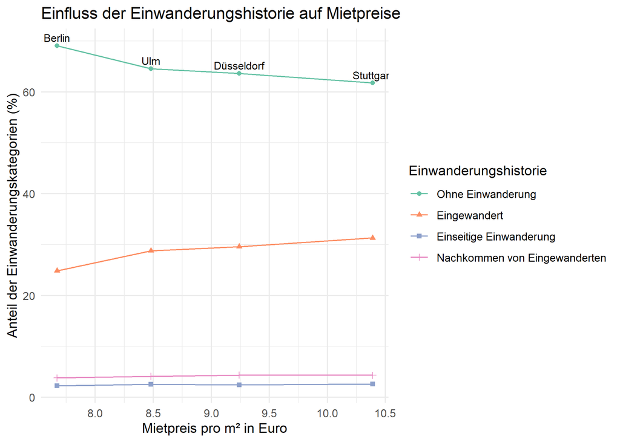

Die Grafik zeigt den Einfluss der Einwanderungshistorie auf die Mietpreise in Berlin, Ulm, Düsseldorf und Stuttgart. Wie zuvor repräsentieren die untereinander angeordneten Punkte jeweils eine der vier Städte.

Ein auffälliger Trend ist erkennbar: Mit steigendem Prozentsatz an Eingewanderten steigen auch die Mietpreise. Berlin weist mit der niedrigsten Einwanderungsquote die günstigsten Mietpreise auf, während Stuttgart mit der höchsten Einwanderungsquote die höchsten Mietpreise verzeichnet. Zudem zeigt sich, dass Berlin mit knapp 70 % den größten Anteil an Personen ohne Einwanderungsgeschichte hat, während Stuttgart mit etwas über 60 % den geringsten Anteil aufweist.

Diese Beobachtungen könnten also einen Zusammenhang zwischen Einwanderungshistorie und Mietpreisen aufzeigen, der natürlich anhand weiterer Daten überprüft werden müsste.

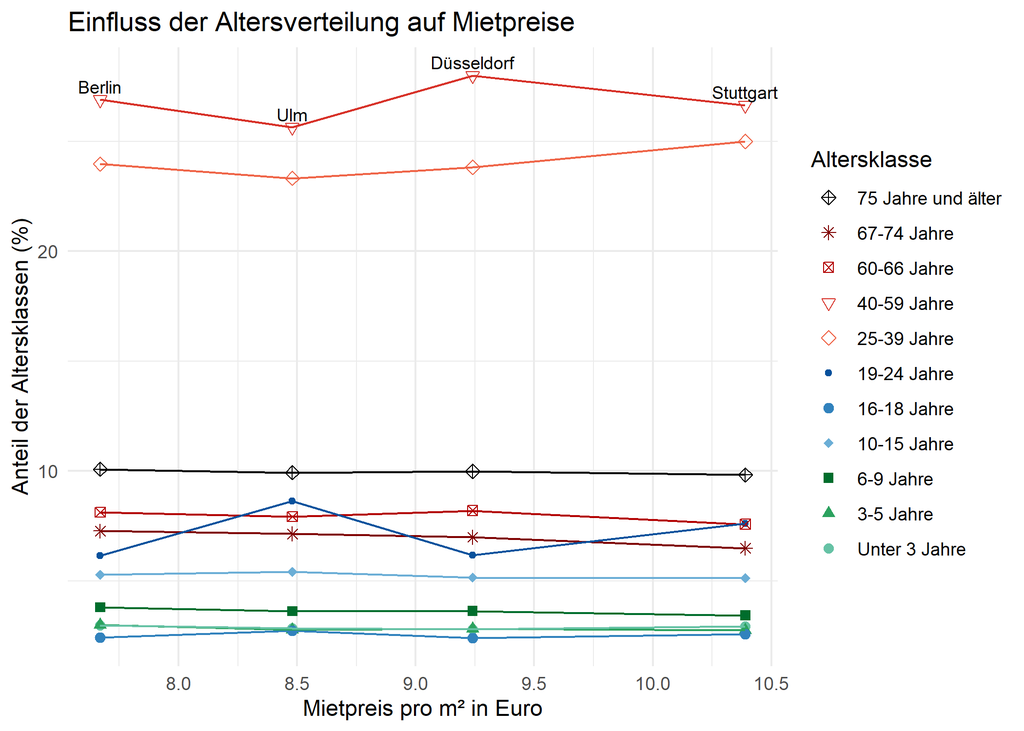

Diese Grafik beleuchtet den Einfluss der Altersverteilung auf die Mietpreise in den Städten Berlin, Ulm, Düsseldorf und Stuttgart. Basierend auf den vorliegenden Daten, die die verschiedenen Altersgruppen prozentual an der Gesamtbevölkerung jeder Stadt gewichten, lassen sich leichte Muster erkennen.

Eine auffällige Beobachtung ist, dass in Ulm die Altersgruppe den 19- bis 24-Jährigen stärker vertreten ist als in den anderen drei Städten. Dies könnte auf eine verstärkte Präsenz von Studierenden oder jungen Fachkräften hinweisen. Im Gegensatz dazu ist die Gruppe der 40- bis 59-Jährigen in Ulm am geringsten vertreten, während Düsseldorf in diesem Alterssegment die Spitze anführt. Dieser Unterschied könnte auf verschiedene Faktoren wie Arbeitsmarktstrukturen oder regionale demografische Entwicklungen zurückzuführen sein.

Die Grafik zeigt, dass die Altersverteilung in Berlin, Ulm, Düsseldorf und Stuttgart sonst recht ähnlich ist. Dies bedeutet, dass man nicht einfach das Alter der Bewohner als Grund für unterschiedliche Mietpreise ansehen kann.

In den bisherigen Analysen wurden demografische und wohnungsbezogene Faktoren in verschiedenen Städten Deutschlands untersucht. Dabei lag der Fokus darauf, wie diese Merkmale in unterschiedlichen Regionen das Mietpreisniveau und dessen Struktur beeinflussen. Aufbauend auf diesen Erkenntnissen soll der Blick nun gezielt auf den Vergleich zwischen Ost- und Westdeutschland gelenkt werden. Diese regionale Differenzierung ermöglicht es, potenzielle Unterschiede und Gemeinsamkeiten zwischen den beiden Landesteilen genauer zu analysieren. Insbesondere wird betrachtet, wie sich die Mietpreisstruktur in Ost- und Westdeutschland darstellt und ob sich hierbei spezifische Muster oder Abweichungen erkennen lassen.

**10. Betrachten Sie nun die Städte `Dresden, Stadt`, `Chemnitz, Stadt`, `Stuttgart, Landeshauptstadt`, `Ulm, Universitätsstadt`,`Düsseldorf, Stadt`und `Berlin, Stadt`. Vergleichen Sie in einem ersten Schritt die Anzahl an Einwohnern, den Anteil an Menschen, die deutscher Herkunft sind, den Anteil an neuen und alten Wohnungen, sowie die durchschnittlichen Mietpreise. Erweitern Sie ihre Analyse um die durschnittlichen Wohnflächen.**

Erstellen Sie für die genannten Städte eine deskriptive Tabelle. Beschreiben und interpretieren Sie diese. Beantworten Sie insbesondere folgende Fragen:

- In wie weit könnte das Alter der Wohnungen eine Rolle für den Mietpreis spielen?
- Gibt es Auffälligkeiten zwischen den einzelnen Städten in Bezug auf Herkunft der Bewohner, Einwohner und Größe der Wohnungen?
- Warum könnte es problematisch sein, wenn Sie die Städte als ein Ganzes betrachten?
- Sind Ihre Ergebnisse auf die ganze Stadt verallgemeinerbar?
- Was sind ihrer Meinung nach Faktoren, die die unterschiedlichen Mietpreise in Ost und West erklären?
- Welche Maßnahmen wären geeignet, um in Düsseldorf, Ulm und Stuttgart die Mietpreisstruktur anzupassen und bezahlbaren Wohnraum zu schaffen?

| Gemeinde | Anzahl Einwohner | Anteil deutsche Herkunft (in %) | Anteil neue Wohnungen (in %) | Anteil alte Wohnungen (in %) | Durchschn. Nettokaltmiete pro qm (in €) | Durchschnittliche Fläche (in qm) |
| --- | --- | --- | --- | --- | --- | --- |
| Düsseldorf, Stadt | 611258 | 63.64 | 5.78 | 22.11 | 9.24 | 77.56 |
| Stuttgart, Landeshauptstadt | 610458 | 61.77 | 6.57 | 31.33 | 10.39 | 79.76 |
| Ulm, Universitätsstadt | 127116 | 64.58 | 9.26 | 19.02 | 8.48 | 87.64 |
| Berlin, Stadt | 3596999 | 69.08 | 5.92 | 39.72 | 7.67 | 73.22 |
| Chemnitz, Stadt | 240078 | 85.86 | 3.18 | 41.03 | 5.26 | 71.33 |
| Dresden, Stadt | 557782 | 86.01 | 6.62 | 39.61 | 6.92 | 71.24 |

Die Tabelle listet für die Städte Düsseldorf, Stuttgart, Ulm, Berlin, Chemnitz und Dresden jeweils die Anzahl der Einwohner, den Anteil der Einwohner mit deutscher Herkunft, den Anteil an neuen Wohnungen, den Anteil an alten Wohnungen, die durchschnittliche Nettokaltmiete pro qm in € sowie die durchschnittliche Fläche in qm auf.

Es gibt auch Auffälligkeiten zwischen den Städten in Bezug auf Herkunft der Bewohner, Einwohner und Größe der Wohnungen. In den betrachteten Städten fallen hier insbesondere Stuttgart, Düsseldorf und Ulm auf, da hier die durchschnittliche Wohnfläche am größten ist. Gleichzeitig ist in denselben Städten der Anteil der Menschen deutscher Herkunft am geringsten im Vergleich zu den anderen Städten. Dies könnte auf eine höhere Nachfrage nach größeren Wohnräumen von Menschen ohne deutsche Herkunft hinweisen.

Die Städte als Ganzes zu betrachten kann problematisch sein, da sie oft sehr ungleich verteilt sind, besonders wenn sie größer sind. Es gibt meistens verschiedene Stadtviertel, in denen die Spanne zwischen arm und reich sehr groß ist. Städte mit großen, wohlhabenden Vierteln können den Durchschnitt sowohl der Wohnfläche als auch der Mietpreise stark nach oben ziehen, was die Daten verzerren kann.

Die Ergebnisse einer Analyse auf Stadtebene sind daher nicht immer verallgemeinerbar. Stadtteile können sich in Bezug auf Einkommen, Beruf und Nationalität stark unterscheiden.

Die Mietpreise unterscheiden sich in Ost- und Westdeutschland vermutlich aus mehreren Gründen. Nach der Wiedervereinigung hatte der Westen bereits eine starke Wirtschaft und eine gute Infrastruktur, was zu mehr Arbeitsplätzen und höheren Einkommen führte. Dadurch stieg die Nachfrage nach Wohnraum und damit auch die Mieten. Im Westen ist zudem das Durchschnittsgehalt deutlich höher und es gibt deutlich mehr große Städte, was ebenfalls die Preise erhöht. Im Osten gibt es oft weniger Menschen und weniger wirtschaftliche Entwicklung, daher ist die Mietnachfrage dort auch geringer. Außerdem wirken sich politische Maßnahmen unterschiedlich auf die Mietpreise aus. All diese Faktoren führen dazu, dass die Mieten im Westen oft höher sind als im Osten.

Um in Städten wie Düsseldorf, Ulm und Stuttgart die Mietpreisstruktur anzupassen und bezahlbaren Wohnraum zu schaffen, wären Maßnahmen geeignet, wie zum Beispiel die Förderung des sozialen Wohnungsbaus, Modernisierungsprogramme, die Einführung von Mietpreisbremsen und die Förderung von alternativen Wohnmodellen. Diese Maßnahmen könnten dazu beitragen, dass der Wohnraum in diesen Städten wieder leichter zu bezahlen wird.

**11. Lesen Sie den [folgenden Artikel](https://www.tagesschau.de/wirtschaft/sozialwohnungen-bau-mangel-101.html). Dort werden Sozialwohnungen thematisiert, warum so viele fehlen und wer davon vor allem betroffen ist. Beantworten Sie anschließend folgende Fragen:**

- Welche Bevölkerungsgruppen sind am stärksten von der Sozialwohnungsnot betroffen und inwiefern?
- Was sind Gründe, warum es zu wenige Sozialwohnungen gibt?
- Wie sieht die historische Entwicklung des Sozialwohnungsbaus aus, im Hinblick auf Vorhandensein von Wohnungen und Investitionen in den Bau von neuen Wohnungen?
- Welche Anreize könnten Investoren motivieren, mehr Sozialwohnungen zu bauen?
- Welche innovativen Ansätze können Bauherren verfolgen, um die Kosten für den Wohnungsbau zu senken?

**Welche Bevölkerungsgruppen sind am stärksten von der Sozialwohnungsnot betroffen und inwiefern?**

Besonders ärmere Familien sind von der Sozialwohnungsnot betroffen, da es ein immer knapper werdendes Angebot auf dem gesamten Wohnungsmarkt gibt und dieses dazu führt, dass die Mieten weiter stiegen. Auf dem normalen Wohnungsmarkt haben finanziell schwache Wohnungssuchende kaum eine Chance, eine bezahlbare Wohnung zu finden. Selbst die, die einen Wohnberechtigungsschein haben, bekommen oft keine Sozialwohnung, weil einfach nicht genug Wohnungen verfügbar sind.

**Was sind die Gründe, warum es zu wenige Sozialwohnungen gibt?**

Die Ziele der Regierung beim Bau von Sozialwohnungen wurden jahrelang krachend verfehlt. Hauptursachen dafür sind die stark steigenden Zinsen und Baukosten. Zudem gibt es durch den Krieg und die damit einhergehende Krise in der Ukraine große Schwierigkeiten bei den Lieferketten. Bauvorhaben, egal ob gefördert oder nicht, werden immer teurer. Früher konnten Investoren auch bei geförderten Projekten mit Mieten um die sechs Euro noch Gewinne erzielen, doch mittlerweile werden diese Gewinne von den Kosten aufgezehrt. Daher macht es für die Investoren teilweise keinen Sinn mehr, neue Wohnungen zu bauen. Ein weiterer entscheidender Grund ist der Mangel an Fachkräften im Baugewerbe.

**Wie sieht die historische Entwicklung des Sozialwohnungsbaus aus, im Hinblick auf Vorhandensein von Wohnungen und Investitionen in den Bau von neuen Wohnungen?**

Die historische Entwicklung des Sozialwohnungsbaus in Deutschland zeigt einen deutlichen Rückgang seit den neunziger Jahren. Damals gab es etwa drei Millionen Sozialwohnungen, während es heute nur noch rund 1,1 Millionen sind. Grund dafür sind unzureichende Investitionen in den Neubau von Sozialwohnungen, bedingt durch steigende Baukosten und Zinsen, sowie durch Lieferkettenprobleme ausgelöst durch die Ukraine-Krise. Dadurch ist die Attraktivität für Investitionen in Sozialwohnungen stark gesunken, weshalb die politischen Ziele beim Sozialwohnungsbau auch deutlich verfehlt wurden. Obwohl der Bedarf deutlich gestiegen ist, gibt es immer weniger Wohnungen.

**Welche Anreize könnten Investoren motivieren, mehr Sozialwohnungen zu bauen?**

Mit deutlich höheren staatlichen Förderungsmitteln würden wieder Anreize für Investoren entstehen. Mit weniger Auflagen und schnelleren Genehmigungen könnte das Bauen einfacher, schneller und damit billiger werden und dadurch ließe sich schnell mehr Bauland erschließen. Dies könnte durch günstigere Kredite, Steuervergünstigungen oder geringere regulatorische Auflagen geschehen.

**Welche innovativen Ansätze können Bauherren verfolgen, um die Kosten für den Wohnungsbau zu senken?**

Bauherren können die Baukosten durch mehrere Ansätze reduzieren. Dazu gehört der Bau kleinerer Treppenhäuser, die Verringerung der Wandstärke, die Wahl von Holzbau statt Mauerstein und das Planen von Flachdächern ohne Attika. Im Bereich des Schallschutzes ist kein zusätzlicher Bedarf, da bereits hohe Standards erreicht sind. Es braucht Innovationen, die nicht aus Verwaltungen kommen, sondern von der Industrie entwickelt werden. Entscheidend ist, diese Innovationen voranzutreiben, um effizienter und kostengünstiger zu bauen – statt nur auf regulatorische Erleichterungen zu warten. Sozialer Wohnungsbau ist außerdem für Anleger ein gutes Investment, da die Wohnungen stark nachgefragt sind. Es gibt kaum Fluktuation und fast keine Leerstände. Die Wohnungen haben oft denselben Standard wie nicht geförderter Wohnraum, und Investoren können sich ihr soziales Engagement auf die Fahnen schreiben.

**12. Gerade die Politik ist gefordert, bezahlbaren Wohnraum zu realisieren. Dabei gibt es eine Vielzahl an politischen Maßnahmen, die aufgestellt wurden und umfangreich diskutiert werden.** **Betrachten Sie die folgenden Maßnahmen, welche helfen sollen, die angespannte Lage auf dem Mietmarkt zu entlasten. Argumentieren Sie, warum diese Maßnahmen sinnvoll/nicht sinnvoll sind und in welcher Art und Weise diese umgesetzt werden können.**

1. “Fachleute fordern, die Regulierung von Bestandsmieten zu lockern, damit sich ihr Niveau den Neuvertragsmieten annähert, mehr Menschen umziehen und sich Wohnraum besser verteilt.”
2. “Eine weitere Möglichkeit wäre, Mieterhöhungen bei Neuvertragsmieten zu begrenzen.”
3. “Am einfachsten ist es, wenn vor allem in Großstädten, wo bezahlbarer Wohnraum fehlt, mehr gebaut wird.”
4. “Am besten wäre es, wenn zukünftig mehr Vermieter in regelmäßigen Abständen die Miete anpassen.”

**1. “Fachleute fordern, die Regulierung von Bestandsmieten zu lockern, damit sich ihr Niveau den Neuvertragsmieten annähert, mehr Menschen umziehen und sich Wohnraum besser verteilt.”**

Aktuell gibt es strenge Richtlinien bezüglich der Mieterhöhung für langjährige Mieter. Dies sorgt dafür, dass Neumieter für den gleichen Wohnraum mehr bezahlen als Bestandsmieter. Würde die Regulierung von Bestandsmieten gelockert, könnte dies dafür sorgen, dass Bestandsmieten und Neumieten sich annähern und die ungerechte Verteilung geregelt wird. Durch die Lockerung der Regularien für Bestandsmieten könnten auch alleinstehende Personen, die in großen Wohnungen leben, dazu gebracht werden, in kleinere Wohnungen umzuziehen und so Platz zu schaffen für größere Personenhaushalte. Der bestehende Wohnraum kann so effizienter genutzt werden.

Diese Maßnahme kann aber auch dafür sorgen, dass Mieter, die ihre gewohnte Umgebung nicht verlassen möchten oder aus beruflichen oder familiären Gründen dort leben, in finanzielle Schwierigkeiten geraten. Vermieter könnten unter Umständen die Mieten schneller anheben, was den finanziellen Druck für Mieter erhöht, besonders in einkommenschwachen Haushalten.

Es wäre eine Möglichkeit diese Maßnahme langsam umzusetzen, um Mieter zu schützen.

**2. “Eine weitere Möglichkeit wäre, Mieterhöhungen bei Neuvertragsmieten zu begrenzen.”**

Regelungen für Mieterhöhungen bei Neuvertragsmieten sind weniger streng, als bei Bestandsmieten. Dies führt zu dazu, dass Neuvertragsmieten deutlich über den Bestandsmieten liegen, worunter neue Mieter leiden. Die Maßnahme bietet einkommenschwacheren Haushalten bessere Chancen in größeren Stadtteilen zu leben. Eine Begrenzung könnte also dazu führen, dass der Markt sich stabilisiert und schnell steigende Mietpreise bei neuen Mietverträgen verhindert werden. Die finanzielle Belastung für Neumieter wäre somit reduziert.

Dies könnte aber auch Auswirkungen auf die Entscheidungen von Vermietern haben. Ihre Bereitschaft Wohnungen zu vermieten könnte sinken, da sie weniger Gewinne erzielen.

Eine Möglichkeit, diese Maßnahme dennoch umzusetzen, wäre den Mietspiegel anzupassen.

**3. “Am einfachsten ist es, wenn vor allem in Großstädten, wo bezahlbarer Wohnraum fehlt, mehr gebaut wird.”**

Ein größeres Angebot an Wohnraum kann dazu beitragen, die steigende Nachfrage zu decken und die Mietpreise zu stabilisieren. Mehr Menschen bekommen so Zugang zu bezahlbarem Wohnraum. Die angespannte Situation auf dem Mietmarkt würde so gelindert werden und einkommensschwache Haushalte werden nicht verdrängt. Außerdem würde die Bauwirtschaft angekurbelt werden.

Andererseits ist Baufläche vor allem in großen Städten begrenzt und der Neubau teuer. Die neuen Wohnungen sind also von vorn herein teurer. Der Bau neuer Wohnungen benötigt auch Zeit.

Die Maßnahme könnte umgesetzt werden, indem öffentliche Fördermittel bereitgestellt werden, um die Kosten zu senken. Um genügend Bauplatz zu haben, könnte man leerstehende Gebäude oder ungenutzte Flächen in Wohnraum umwandeln.

**4. “Am besten wäre es, wenn zukünftig mehr Vermieter in regelmäßigen Abständen die Miete anpassen.”**

Kontinuierliche, kleine Mietanpassungen statt seltener und hoher Erhöhungen belastet die Mieter weniger und unterstützt die Vermieter dabei, Instandhaltungs- und Energiekosten planbar zu decken.

Regelmäßige Anpassungen sorgen aber auch dafür, dass Mieten langfristig stetig steigen, auch wenn Gehälter nicht im gleichen Tempo wachsen. Das belastet die Mieter finanziell und Vermieter werden angeregt, die Obergrenzen für erlaubte Mieterhöhungen voll auszuschöpfen. Diese Maßnahme betrifft hauptsächlich Bestandsmieter, was als ungerecht empfunden werden könnte.

Die Maßnahme könnte dennoch eine Chance bieten, wenn gleichzeitig auch eine angemessene Höchstgrenze für regelmäßige Erhöhungen festgelegt wird. Hier ist es sinnvoll, dass neue gesetzliche Regelungen erstellt werden, um die Mieter zu schützen.

# Einzelne Stadtteile in Deutschland

In allen vorherigen Aufgaben haben Sie die Städte, Gemeinden oder auch Landkreise immer als ein Ganzes betrachtet. Jedoch ist es schwierig gerade in Großstädten wie Berlin, Düsseldorf oder auch Stuttgart allgemeine Aussagen über die Mietsituation auf Stadtebene zu treffen. Dies liegt unter anderem daran, dass unterschiedliche Stadtviertel unterschiedliche demografische Eigenschaften, sowie eine unterschiedliche Mietstruktur aufweisen können. Hier wäre es sinnvoll sich mit dem Stadtbild und der Verteilung der Mieten genauer auseinanderzusetzen, um zu sehen, wie sich Mieten innerhalb der Stadt verteilen. Wie in Aufgabe 10 zu sehen war, weisen die Städte im Westen Deutschlands untereinander, sowie die Städte im Osten ähnliche Merkmale auf, weshalb Sie sich in den folgenden Aufgaben auf je eine große und eine kleinere Stadt aus beiden Regionen konzentrieren.

**13. In dieser Aufgabe sollen Sie ihren Datensatz aus Aufgabe 4, bei dem Sie Kartendaten und Informationen zu Mieten und LEQ auf 1km-Gitterebene heruntergeladen und zusammengefügt haben, verwenden und vier Karten zeichnen, welche die Verteilung der Nettokaltmieten in den Stadtteilen der Städte “Stuttgart, Landeshauptstadt”, “Ulm, Universitätsstadt”, “Chemnitz, Stadt” und “Dresden, Stadt” anschaulich visualisieren.**

Erstellen Sie vier Grafiken, beschreiben und interpretieren diese. Gehen Sie insbesondere auf folgende Fragen ein:

- Welche Besonderheiten fallen Ihnen bei diesen Städten auf?
- Gibt es eine Segregation in Bezug auf die Mieten in einzelnen Stadtteilen?
- Falls es eine Segregation gibt, welche Konsequenzen könnte dies haben?
- Welche Rolle spielen geografische oder infrastrukturelle Faktoren bei den Mietpreisen?
- Gibt es Unterschiede zwischen Städten im Osten und Westen Deutschlands, falls ja, welche Einflüsse in Bezug auf Wirtschaft und Arbeitsmarkt könnte dies in den jeweiligen Städten haben?

*Hinweis:* Wenn Sie einheitliche Legenden für die Karten haben möchten und die vier Städte nebeneinander oder untereinander darstellen wollen, so empfiehlt sich das Paket `ggpubr` und dort der Befehl `ggarrange`.

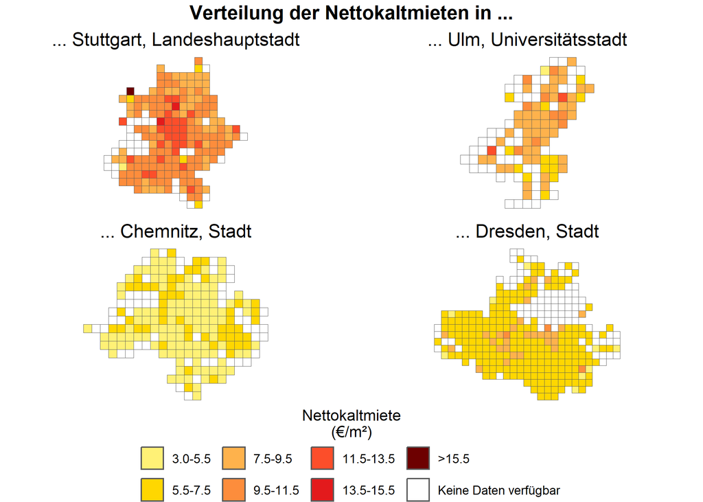

In Stuttgart, wo die Nettokaltmiete am höchsten ist im Vergleich zu den anderen drei Städten, kann man feststellen, dass die Mieten im Stadtzentrum etwas höher sind als in den Randbezirken. Ein bemerkenswerter Ausreißer im Nordwesten deutet auf ein besonders teures Wohnviertel hin oder könnte ein Bezirk mit wenigen Wohnungen sein, in dem einige sehr teure Mietobjekte den durchschnittlichen Mietpreis nach oben treiben. In Ulm hingegen scheinen die Mietpreise relativ gleichmäßig verteilt zu sein. Es gibt jedoch eine leichte Clusterbildung im Norden und Westen, möglicherweise beeinflusst durch die Nähe zur Universität im Nordwesten der Stadt.

Chemnitz zeigt eine relativ homogene Mietstruktur, wobei hier auffällig ist, dass die Mietpreise im Stadtzentrum nicht höher liegen, wie normalerweise üblich, was auf eine geringere soziale oder wirtschaftliche Segregation hindeuten könnte. Das Mietniveau ist insgesamt moderat, was die wirtschaftlichen Bedingungen in der Region widerspiegeln könnte. Die Mietverteilung in Dresden ähnelt der in Chemnitz, wobei in Dresden die Mieten im Stadtzentrum etwas höher sind als in den äußeren Bezirken.

In Bezug auf die Segregation der Mieten zeigt Stuttgart eine stärkere räumliche Trennung zwischen hohen und niedrigen Mietniveaus. Im Gegensatz dazu ist die Mietverteilung in ostdeutschen Städten wie Chemnitz und Dresden tendenziell homogener, was auf geringere Einkommensunterschiede oder weniger stark ausgeprägte Nachfrageunterschiede hinweisen könnte.

Die Segregation in Städten wie Stuttgart kann soziale Konsequenzen haben. Hohe Mietpreise in bestimmten Gebieten könnten sozial benachteiligte Gruppen verdrängen, was zu Spannungen und ungleichem Zugang zu Ressourcen wie Bildung und Gesundheitsversorgung führt. Wirtschaftlich gesehen kann die Konzentration Wohlhabender in bestimmten Vierteln zu Gentrifizierung führen, während Geringverdiener in schlechter erschlossene Randgebiete gedrängt werden.

Was geografische und infrastrukturelle Faktoren betrifft, ist in Stuttgart vor allem die große Wirtschaft zu betrachten, besonders die Automobilindustrie. Das kann ein guter Grund sein, dass die Mieten in zentralen Lagen nach oben gehen. In Ulm beeinflusst die Nähe zur Universität die Mietpreise durch die hohe Studentennachfrage. In Chemnitz und Dresden hingegen wirkt sich die historisch bedingt schwächere Wirtschaft auf die niedrigeren Mieten aus.

**14. Nachdem Sie in Aufgabe 13 die Verteilung der Mieten der einzelnen Stadtteile visualisiert haben, sollten Sie in dieser Aufgabe den Anteil der Leerstandsquoten in den Stadtteilen der Städte “Stuttgart, Landeshauptstadt”, “Ulm, Universitätsstadt”, “Chemnitz, Stadt” und “Dresden, Stadt” veranschaulichen.**

Erstellen Sie vier Grafiken, beschreiben und interpretieren diese. Gehen Sie insbesondere auf folgende Fragen ein:

- Was könnten Gründe sein, dass die Leerstandsquote in bestimmten Stadtteilen höher ist, als in anderen?
- Welche Besonderheiten fallen Ihnen bei diesen Städten auf? Auch im Hinblick auf ihre Erkenntnisse aus Aufgabe 13.
- Vergleichen Sie die Grafiken aus Aufgabe 13 und Aufgabe 14. Was könnte der Grund für die unterschiedlichen Muster sein?
- Welche Maßnahmen ergreifen Städte mit hohen Leerstandsquoten, um diese zu reduzieren?

*Hinweis:* Wenn Sie einheitliche Legenden für die Karten haben möchten und die vier Städte nebeneinander oder untereinander darstellen möchten, so empfiehlt sich das Paket `ggpubr` und dort der Befehl `ggarrange`.

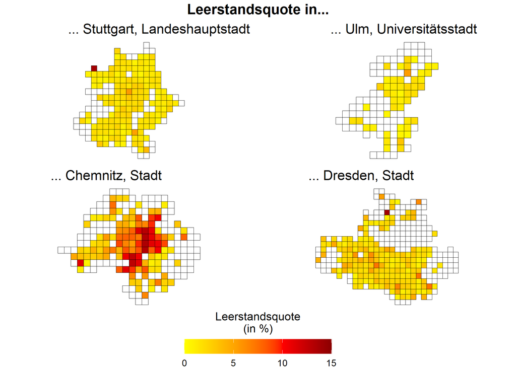

Diese Grafiken zeigen für Stuttgart, Ulm, Chemnitz und Dresden die Leerstandsquoten in Prozent in den einzelnen Stadtteilen. Je rötlicher diese Stadtteile gefärbt sind, desto höher ist dort die Leerstandsquote.

Ein wesentlicher Grund, warum in bestimmten Stadtteilen höhere Leerstandsquoten bestehen, könnte die wirtschaftliche Attraktivität oder der infrastrukturelle Zugang sein. Stadtteile, die weniger gut angebunden sind oder ein geringeres Angebot an Arbeitsplätzen, Bildungseinrichtungen und Freizeitmöglichkeiten aufweisen, könnten weniger attraktiv für Mieter sein. Dies kann zu höheren Leerstandsquoten führen. Ebenso könnten bauliche Mängel oder Altbauten in bestimmten Gebieten potenzielle Mieter abhalten, sich dort eine Wohnung zu mieten.

In Stuttgart sind die Leerstandsquoten extrem gering, was auf eine konstante Nachfrage und die Attraktivität der Stadt hinweist. Die minimale Anzahl an leerstehenden Immobilien im Stadtzentrum steht im Kontrast zu den hohen Mietkosten, die sich viele leisten können oder wollen. Diese Dynamik könnte mit der robusten wirtschaftlichen Lage und den guten Infrastrukturbedingungen zusammenhängen.

In Chemnitz sind die Leerstandsquoten am höchsten im Vergleich zu den anderen drei ausgewählten Städten. Diese hohen Werte deuten auf eine geringere wirtschaftliche Dynamik und möglicherweise unzureichende Investitionen in bestimmten Stadtvierteln hin. Solche Gebiete könnten weniger attraktiv für potenzielle Mieter sein, was zu einem Überangebot an leerstehenden Immobilien führt. Besonders im Stadtzentrum sind die Leerstandsquoten mit nicht selten über 10% sehr hoch.

Ulm und Dresden zeigen gemischte Muster bei den Leerstandsquoten. In Ulm könnten geringere Leerstände durch die stabile Nachfrage aufgrund der Universitätsnähe gestützt werden, was die Attraktivität bestimmter Gebiete erhöht. Dresden wiederum weist in einigen Teilen Leerstände auf, es gibt jedoch auch Gegenden mit niedrigen Leerstandsquoten. Diese unterschiedlichen Verteilungen sind wahrscheinlich auf die variierende wirtschaftliche Aktivität und Investitionsbereitschaft innerhalb der Stadt zurückzuführen.

Der Vergleich der Grafiken aus Aufgabe 13 (Mieten) und Aufgabe 14 (Leerstand) zeigt, dass in Stadtteilen mit hohen Mieten öfters auch mehr Leerstand zu finden ist. Das liegt wahrscheinlich daran, dass viele sich die teuren Mieten einfach nicht leisten können, weshalb viele Wohnungen leer stehen. In Gegenden mit niedrigeren Mieten gibt es dagegen eher weniger Leerstand. Diese Viertel sind wegen der günstigeren Preise für viele Leute anziehender, was dazu führt, dass die Nachfrage steigt und weniger Leerstand entsteht.

In Stuttgart ist in einem Stadtteil im Nordwesten, in dem die Mieten extrem hoch sind, die Leerstandsquote ebenfalls extrem hoch. Dies könnte darauf hindeuten, dass die Mietpreise in diesem Gebiet unerschwinglich sind, selbst für Menschen, die auf der Suche nach hochwertigen Immobilien sind, oder dass das Angebot möglicherweise nicht auf die Bedürfnisse der suchenden Mieter abgestimmt ist.

In Chemnitz sind die Mieten im Stadtzentrum günstiger als in den äußeren Bereichen. Interessanterweise gibt es dort auch besonders hohe Leerstandsquoten, was darauf hindeuten könnte, dass trotz der niedrigeren Mieten keine ausreichende Nachfrage besteht oder dass andere Faktoren wie infrastrukturelle oder soziale Aspekte den Leerstand verursachen.

Städte mit hohen Leerstandsquoten ergreifen verschiedene Maßnahmen, um diese zu reduzieren. Dazu gehören die Sanierung von Altbauten, um sie attraktiver für Mieter zu machen, die Verbesserung der Infrastruktur und der Anbindung des öffentlichen Verkehrs, sowie die Förderung von Entwicklungsprojekten und wirtschaftlichen Initiativen, um die Attraktivität und wirtschaftliche Aktivität der Stadtteile zu erhöhen.

**15. Die aktuellen Mietpreise und deren Entwicklungen hindern in Deutschland immer mehr Menschen daran, dass sie sich eine neue geeignete Wohnung suchen. Personen, die aufgrund ihrer aktuellen Lebenssituation sich nach einer neuen Wohnung umsehen, finden oft keine oder können sich diese nicht leisten. Doch worin liegen die Ursachen und Probleme?**

Beantworten Sie hierzu folgende Fragen:

- Was versteht man unter dem Lock-in-Effekt, speziell in Bezug auf den Mietmarkt? Wer ist davon vor allem betroffen und warum?
- Gibt es aktuell Möglichkeiten, die vor allem diese “betroffenen” Personen haben, um an bezahlbaren Wohnraum zu gelangen?
- Worin liegen die Ursachen, dass Bestandsmieten (Mieten aus bestehenden Verträgen) und Angebotsmieten (Mieten aus Neuverträgen) so stark voneinander abweichen?

Gehen Sie in ihrer Argumentation auch auf die Grafiken und Ergebnisse der Aufgaben 11, 13 und 14 ein.

Unter Lock-in-Effekt versteht man eine Situation, in der Menschen aus finanziellen Gründen nicht umziehen können. Dies passiert häufig dadurch, dass Bestandsmieten günstiger sind im Vergleich zu Neumieten. Es ist demnach schwierig, die höheren Neumieten zu bezahlen und Bestandsmieter sind dazu gezwungen, in ihren Wohnungen weiter zu wohnen, auch wenn sie nicht mehr zur aktuellen Lebenssituation passt. Vom Lock-in-Effekt sind verschiedene Personen und Personengruppen betroffen. Ältere Menschen, die in großen Wohnungen leben, können diese nicht verlassen, da die Neumiete für kleinere Wohnungen zu hoch ist. Umgekehrt können Familien, vor allem Familien mit geringen Einkommen, nicht in größere passendere Wohnungen umziehen. Allgemein bleiben beispielsweise in Städten mit Segregation Geringverdiener eher in schlechter angebundenen oder weniger attraktiven Vierteln, weil die Umzugskosten in bessere Stadtteile zu hoch sind.

Es gibt verschiedene Möglichkeiten, um dennoch an bezahlbaren Wohnraum zu gelangen. Zum einen könnte ein Wohnberechtigungsschein beantragt werden, um Zugang zu Sozialwohnungen zu bekommen. Jedoch gibt es nur wenig Sozialwohnungen und die Nachfrage kann nicht gedeckt werden, wie schon bereits vorher analysiert wurde. Eine andere Möglichkeit ist es Wohngeld zu beantragen, um die höheren Mietkosten bei einer Neuvermietung abzudämpfen. Wohngeld deckt dann aber nur einen Teil der Belastung. Es könnte auch darüber nachgedacht werden, in Wohngemeinschaften zu leben und so die Kosten aufzuteilen.

Aber worin könnten die Ursachen dafür liegen, dass die Diskrepanz zwischen Bestands- und Neumieten so groß ist? Da Bestandsmieten strengen gesetzlichen Begrenzungen unterliegen, ist es für Vermieter schwieriger, die Miete anzuheben. Neumieten werden jedoch nach der aktuellen Marktlage festgelegt, wobei die Marktlage auch durch die Segregation beeinflusst wird, die Mieten in begehrten Vierteln steigen lässt. Fehlender Wohnraum in Großstädten und steigende Bau- und Instandshaltungskosten sorgen dann zusätzlich dafür, dass Neumieten höher angesetzt werden. Der Mangel an Sozialwohnungen verstärkt dies. Auch hohe Leerstände in den unbeliebteren Wohngegenden sorgen dafür, dass Bestandsmieten zwar günstig bleiben, aber Investitionen in Renovierungen oder die Infrastruktur, um die Leerstände zu veringern, wiederum Neumieten ansteigen lassen. So wird die Diskrepanz zwischen Neumieten und Bestandsmieten immer größer.

*(Quelle: https://www.welt.de/finanzen/immobilien/article171433281/Hohe-Mieten-treiben-viele-Deutsche-in-den-Lock-in-Effekt.html)*

# Stadt vs. Land

Bisher haben Sie sich intensiv mit der Wohnsituation in Deutschland auseinandergesetzt und dabei insbesondere die Unterschiede zwischen Ost- und Westdeutschland betrachtet. Im Fokus standen dabei die Mietpreisentwicklung und die Rolle verschiedener Faktoren wie demografische Merkmale, Leerstandsquote, Eigentümerquote, sowie die Wohnfläche. Diese Analysen haben wertvolle Erkenntnisse über die regionale Dynamik des Mietmarkts geliefert.

Nun sollen Sie ihren Blickwinkel erweitern und den Fokus auf eine weitere Ebene der Analyse richten. Im Kern sollen Sie den Unterschied zwischen städtischen Regionen, insbesondere Großstädten, und ländlichen Gebieten untersuchen. Hierbei soll die Mietstruktur in diesen beiden Raumtypen analysiert werden, ob sich die Strukturen von Stadt und Land voneinander unterscheiden.

**16. Betrachten Sie in einem ersten Schritt die Wohnungen abhängig ihres Alters. Erstellen Sie dazu eine passende Grafik, die die Verteilung der Wohnungen nach Altersgruppen für die Stadt `Stuttgart, Landeshauptstadt` (Landkreis: Stuttgart, Stadtkreis) im Vergleich zum `Alb-Donau-Kreis` und `Ostalbkreis` darlegt.**

Beschreiben und interpretieren Sie ihre Grafik. Woran könnte es liegen, dass es in Stuttgart (in der Stadt) deutlich mehr Altbauwohnungen als auf dem Land gibt? Könnten politische Maßnahmen ihrer Ansicht nach helfen, dass auch in Großstädten mehr neue Wohnungen erbaut und zur Vermietung zur Verfügung gestellt werden?

*Hinweis 1:* Nutzen Sie für die Visualisierung einen Mosaik- oder ein “stacked” Balkendiagramm. Eine Idee, wie Sie das Ganze darstellen können, finden Sie [hier](https://r-graph-gallery.com/).

*Hinweis 2:* Für Stuttgart soll der komplette Landkreis (“Stadtkreis”) untersucht werden.

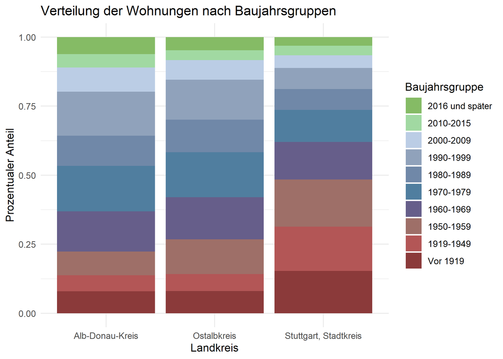

Die Grafik zeigt ein Mosaikdiagramm, das die proportionale Verteilung von Wohnungsbaujahrgruppen in den Landkreisen „Stuttgart, Stadtkreis“, „Alb-Donau-Kreis“ und „Ostalbkreis“ darstellt. Auf der x-Achse sind diese Landkreise aufgelistet, während die y-Achse die prozentualen Anteile der Wohnungen nach ihren Baujahrgruppen angibt. Das Diagramm verdeutlicht, dass in „Stuttgart, Stadtkreis“ ein größerer Anteil der Wohnungsbestände in älteren Baujahrkategorien liegt, insbesondere in den Kategorien „Vor 1919“ und „1919-1949“. Im Gegensatz dazu besitzen die Landkreise „Alb-Donau-Kreis“ und „Ostalbkreis“ einen höheren Anteil an jüngeren Baujahrgruppen, was darauf hinweist, dass in diesen eher ländlichen Regionen mehr Neubauten vorhanden sind.

Die hohe Anzahl an Altbauwohnungen in Stuttgart lässt sich durch mehrere Faktoren erklären. Zum einen ist die Stadt historisch stark gewachsen. Stuttgart als Hauptstadt von Baden-Württemberg beherbergt viele Gebäude, die in Zeiten intensiven städtischen Wachstums errichtet wurden, insbesondere vor und nach den beiden Weltkriegen, als die Bevölkerungszahlen stark anstiegen. Des Weiteren ist der verfügbare Baugrund in städtischen Gebieten wie Stuttgart oft begrenzt, was den Bau neuer Gebäude erschwert. Die dichte bestehende Infrastruktur und der historische Wert vieler Immobilien, die den Abriss zu Gunsten von Neubauten verhindern, sind weitere Gründe. Ebenso sind viele ältere Gebäude unter Denkmalschutz gestellt, was zur Erhaltung gegenüber einem Abriss beiträgt.

Um in Großstädten wie Stuttgart den Bau von neuen Wohnungen zu fördern, könnten verschiedene politische Maßnahmen ergriffen werden. Eine Möglichkeit wären Anreize für Neubauten. Die Regierung könnte Förderprogramme etablieren, die steuerliche Vorteile oder Subventionen für neue Wohnprojekte bieten. Auch die Lockerung von Baurechtsvorschriften könnte es Bauherren erleichtern, neue Projekte zu initiieren, insbesondere durch die Umnutzung bestehender ungenutzter Räume in der Stadt. Weiterhin könnte eine Erhöhung der Bebauungsdichte durch Änderungen in den Flächennutzungsplänen gefördert werden, um mehrstöckige Gebäude zu ermöglichen und das Potenzial des verfügbaren Raums zu maximieren. Schließlich könnte die Stadtverwaltung Maßnahmen ergreifen, um ungenutzte städtische Grundstücke zugänglich zu machen oder öffentliche Flächen, die für Wohnzwecke geeignet sind, freizugeben.

Die Umsetzung solcher Maßnahmen könnte Städte wie Stuttgart unterstützen, mehr neue Wohnungen zu errichten und damit den Wohnungsdruck in wachsenden Städten zu reduzieren. Gleichzeitig sollten diese Maßnahmen unterstützen, die bestehende Infrastruktur und die historischen Gebäude sinnvoll zu integrieren und zu erhalten, um das kulturelle Erbe der Stadt zu bewahren.

**In einem weiteren Schritt sollen Sie nun die Mietpreise und deren Verteilung analysieren. Hierbei sollen Sie neben der Leerstands- und Eigentümerquote auch auf die Verteilung der Wohnungen nach deren Wohnfläche achten und diese untersuchen.**

17 (a). Erstellen Sie zuerst eine Tabelle, die die durchschnittlichen Mietpreise mit der Leerstands- und Eigentümerquote darstellt. Was fällt ihnen dabei besonders auf? Beschreiben und interpretieren Sie ihre Tabelle.

17 (b). Erstellen Sie eine weitere Grafik, die die Verteilung der Wohnungen nach den einzelnen Wohnungsgrößen(<40m² bis >=200m²) abbildet. Stellen Sie darüber hinaus den durchschnittlichen Mietpreis je Landkreis in einer weiteren Grafik dar. Beschreiben und interpretieren Sie ihre Grafiken. Gehen Sie insbesondere auf die Frage ein, ob es Sinn macht sich vor allem den Ostalbkreis oder Alb-Donau-Kreis als ein Ganzes anzusehen und inwieweit überhaupt ein Vergleich zwischen Stadt und ländlicher Region möglich ist.

*Hinweis:* Hier sollen Sie erneut auf dieselben Städte und Landkreise aus Aufgabe 16 eingehen!

**Durchschnittliche Werte für Mietpreis, Leerstands- und Eigentümerquote**

| Landkreis | Durchschnittliche Miete (€/m²) | Leerstandsquote (%) | Eigentümerquote (%) |
| --- | --- | --- | --- |
| Alb-Donau-Kreis | 6.37 | 5.34 | 71.44 |
| Ostalbkreis | 6.27 | 5.09 | 70.59 |
| Stuttgart, Stadtkreis | 10.39 | 3.46 | 31.15 |

Die Tabelle zeigt uns die durchschnittlichen Mietpreise sowie die Leerstands- und Eigentümerquoten in den Regionen „Stuttgart, Stadtkreis“, „Alb-Donau-Kreis“ und „Ostalbkreis“. Die Tabelle gibt an, wie hoch die durchschnittliche Miete pro Quadratmeter in diesen Gebieten ist. Zusätzlich sehen wir, wie viel Prozent der Wohnungen gerade leerstehen und wie viele von den Eigentümern selbst genutzt werden. Die Tabelle fasst also zusammen, was Miete kostet und wie der Wohnraum genutzt wird oder leersteht.

Bei der Untersuchung der Durchschnittswerte für Mietpreise, Leerstandsquoten und Eigentümeranteile in den untersuchten Regionen fällt einiges auf. In “Stuttgart, Stadtkreis” liegen die Mietpreise bei etwa 10 Euro pro qm, was deutlich höher ist als in den Kreisen „Alb-Donau-Kreis“ und „Ostalbkreis“, wo der durchschnittliche Preis bei etwa 6 Euro pro qm liegt. Dieser Unterschied lässt sich gut mit den Gegebenheiten in Stuttgart erklären: Die Stadt bietet viele Arbeitsmöglichkeiten und zieht daher eine hohe Nachfrage nach Wohnraum an. Außerdem sind die Lebenshaltungskosten in städtischen Gebieten wie Stuttgart in der Regel höher.

Ein weiterer Punkt ist die Leerstandsquote. In Stuttgart liegt sie bei etwa 3 %, während sie in den ländlicheren Kreisen bei etwa 5 % liegt. Ein höherer Leerstand kann darauf hinweisen, dass entweder zu viel Wohnraum zur Verfügung steht oder die günstigen Mietpreise weniger anziehend sind. Dies könnte bedeuten, dass zwar genug Wohnraum vorhanden ist, aber die Nachfrage nicht so hoch ist wie in der Stadt.

Der Eigentümeranteil zeigt in Stuttgart mit 30 % einen deutlichen Unterschied im Vergleich zu den ländlichen Gegenden, wo etwa 70 % der Wohnungen im Besitz von Eigentümern sind. Das spricht dafür, dass in den ländlichen Gebieten mehr Menschen dazu neigen, ein Eigenheim zu besitzen, während in der Stadt mehr Menschen mieten, was den Mietmarkt eher belebt und dynamischer werden lässt.

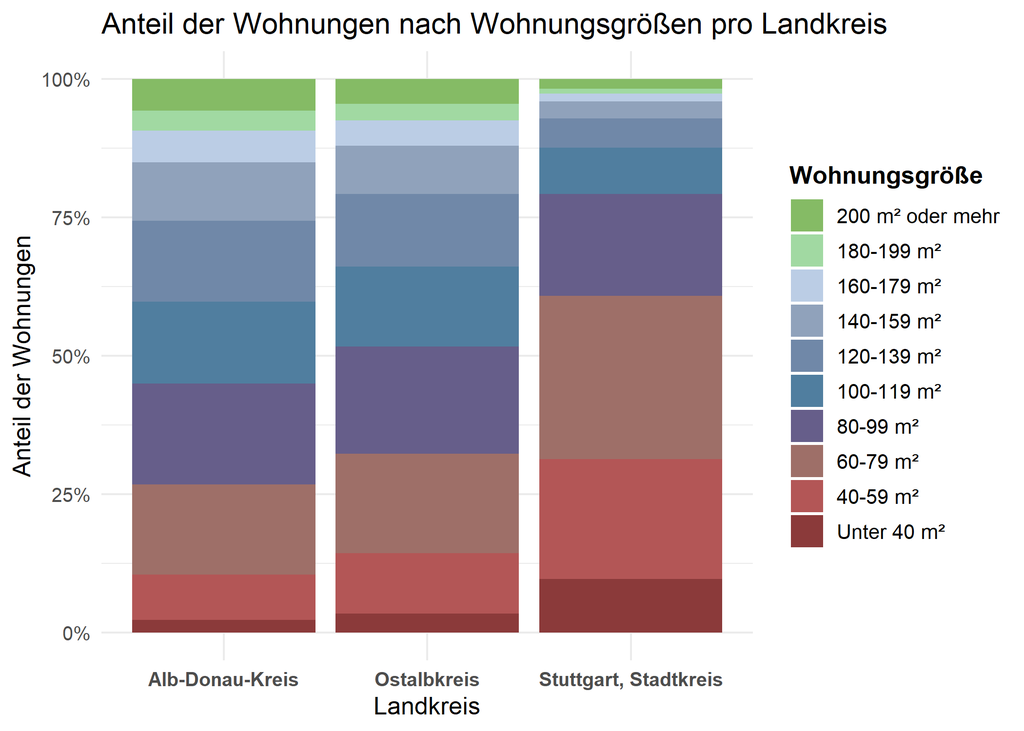

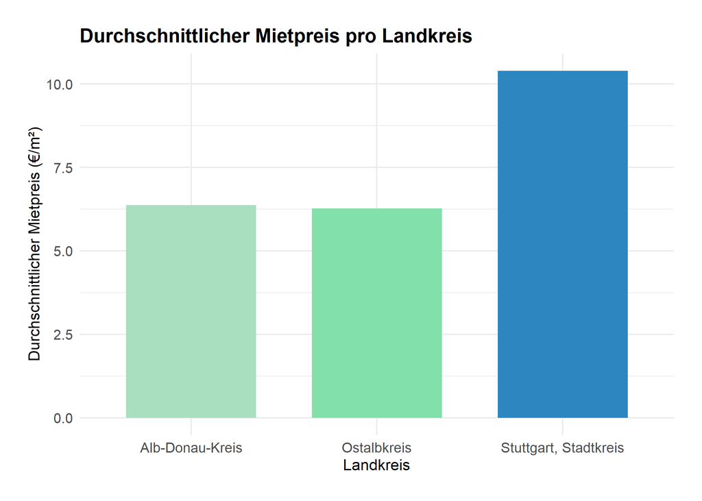

Um die Verteilung der Wohnungen nach den unterschiedlichen Wohnungsgrößen darzustellen sowie den durchschnittlichen Mietpreis in verschiedenen Landkreisen zu verdeutlichen, haben wir zwei Grafiken erstellt. Die erste Grafik zeigt die Anteile der Wohnungen in verschiedenen Größenklassen, die von unter 40 Quadratmetern bis zu 200 Quadratmetern und mehr reichen, für die Landkreise Alb-Donau-Kreis, Ostalbkreis und Stuttgart (Stadtkreis). In Stuttgart fällt auf, dass größere Wohnungen selten sind, was wohl darauf zurückzuführen ist, dass in einer Stadt vor allem kleinere Wohnungen aufgrund der hohen Bevölkerungsdichte und des begrenzten Wohnraums gefragt sind. Im Gegensatz dazu gibt es in den ländlicheren Regionen wie dem Ostalbkreis und dem Alb-Donau-Kreis mehr größere Wohnungen, da dort mehr Platz für größere Wohneinheiten zur Verfügung steht. Wohnungen unter 40 Quadratmetern sind dort vergleichsweise selten.

In der zweiten Grafik wird der durchschnittliche Mietpreis je Landkreis dargestellt. Hier zeigt sich, dass die Mietpreise in Stuttgart deutlich höher sind als in den beiden ländlicheren Kreisen. Der Hauptgrund dafür liegt in der höheren Nachfrage nach Wohnraum in einer Stadt wie Stuttgart, die den Preis in die Höhe treibt. In den ländlichen Kreisen gibt es meist mehr verfügbaren Wohnraum, was die Mietpreise niedriger hält. Auch tragen Unterschiede in der Infrastruktur wie Verkehrsanbindungen, Einkaufsmöglichkeiten und Arbeitsgelegenheiten zu diesen Preisunterschieden bei.

Es ist nicht unbedingt sinnvoll, den Ostalbkreis und den Alb-Donau-Kreis als eine Einheit zu betrachten, da sie sich in ihrer Struktur, Wirtschaft und Geografie stark unterscheiden können. Dennoch, wenn die beiden Regionen in bestimmten Aspekten sehr ähnlich sind, wie hier auch der Fall, könnte es sinnvoll sein, sie zusammenzuführen. Innerhalb eines Landkreises gibt es oft große Unterschiede bei Mieten und Wohnungsgrößen, die man berücksichtigen sollte. Der Vergleich zwischen Stuttgart und ländlichen Gebieten bleibt jedoch herausfordernd, da Städte in der Regel höhere Mietpreise, kleinere Wohnungen und eine höhere Wohndichte haben. Ländliche Gebiete sind dagegen oft durch niedrigere Mieten, größere Wohnungen und mehr Einfamilienhäuser gekennzeichnet. Dennoch kann es hilfreich sein, solche Vergleiche anzustellen, insbesondere wenn man sich auf bestimmte Wohnungsgrößen oder Zielgruppen wie Familien oder Singles konzentriert.

Zusammenfassend zeigt die Interpretation der Daten, dass Wohnungsgrößen und Mietpreise stark vom urbanen oder ländlichen Kontext abhängen. Ein pauschaler Vergleich, etwa Alb-Donau-Kreis und Ostalbkreis als Einheit, wäre wenig zielführend, da jede Region ihre individuellen Besonderheiten aufweist. Der Vergleich zwischen Stadt und Land verdeutlicht zudem Unterschiede in Wohnungsangebot und Nachfrage, insbesondere in Bezug auf Mietpreise und Größenverteilung.

# Zusatzfrage (optional)

Diese Frage ist von der Bearbeitung her etwas schwieriger. Bevor Sie sich an diese Aufgabe machen, sollten Sie sicherstellen, dass Sie alle vorherigen Fragen ausführlich beantwortet haben. Eine korrekte Beantwortung dieser Frage gibt einen Punktebonus von 3 Punkten (das Projekt umfasst insgesamt 30 Punkte, inkl. Screencast).

Nachdem Sie sich in den bisherigen Aufgaben ausführlich mit den allgemeinen Einflussfaktoren auf die Mietpreise befasst haben, rückt nun ein spezifischer Aspekt in den Fokus: die Rolle der Heizungen. Insbesondere werden Sie untersuchen, wie unterschiedliche Heizungsarten und -systeme die Mietpreise beeinflussen können. Diese Betrachtung ermöglicht es ihnen, die bisherigen Analysen zu verfeinern und den Zusammenhang zwischen energetischen Standards und der Entwicklung von Mietkosten genauer zu erfassen. Aufgabe 18 führt Sie somit zu einem weiteren zentralen Detail der Mietpreisentwicklung, das insbesondere vor dem Hintergrund steigender Energiepreise und der Relevanz nachhaltiger Wohnformen an Bedeutung gewinnt.

**18. Lesen Sie den Datensatz `Heiztypen_Zensus.csv` ein und speichern diesen als `heiztypen` ab. Neben den Ihnen bekannten Variablen, finden Sie dort 6 weitere Variablen, die Auskunft über die Heizarten der jeweiligen Wohnung geben. Diese werden wie folgt beschrieben:**

- HEIZTYP__1: Gebäude mit Heizungsart Fernheizung (Fernwärme) (Anzahl)
- HEIZTYP__2: Gebäude mit Heizungsart Etagenheizung (Anzahl)
- HEIZTYP__3: Gebäude mit Heizungsart Blockheizung (Anzahl)
- HEIZTYP__4: Gebäude mit Heizungsart Zentralheizung (Anzahl)
- HEIZTYP__5: Gebäude mit Heizungsart Einzel- oder Mehrraumöfen (auch Nachtspeicherheizung) (Anzahl)
- HEIZTYP__6: Gebäude mit Heizungsart Keine Heizung im Gebäude oder in den Wohnungen (Anzahl)

Erstellen Sie eine neue Spalte `heiztypen_gesamt`, welche die Summe über alle Heiztypen hinweg bildet. Bestimmen Sie weiterhin den Anteil der jeweiligen Heiztypen je Gemeinde (als Anteil aller Heizarten). Nun sollen Sie eine oder mehrere passende Grafik(en) erzeugen, die je nach durchschnittlicher Größe der Wohnungen die Anteile der verschiedenen Heizungsarten abbilden. Erstellen Sie weiterhin eine oder mehrere passende Grafik(en) die den Zusammenhang zwischen den Heizungsarten und den durschnittlichen Mietpreisen darstellt. Wiederum soll der Anteil der verschiedenen Heizungsarten abhängig der Mietpreise abgebildet werden.

Beschreiben und interpretieren Sie ihre Schaubilder und gehen Sie insbesondere auf folgende Frage ein:

- Gibt es einen Zusammenhang zwischen der Heizungsart und der Größe der Wohnungen?
- Gibt es einen Zusammenhang zwischen der Heizungsart und den Mietpreisen?
- Was könnten Gründe sein, warum in bestimmten Wohnungsgrößen eher bestimmte Heizungstypen eingebaut werden und andere nicht?
- Warum könnte es sein, dass bei manchen Heizungsarten die Mietpreise höher sind als bei anderen?
- Was könnte die Bundesregierung machen, um trotz neuer und moderner Heizungssysteme die Mietpreise nach oben hin zu beschränken?

*Hinweis 1:* Überlegen Sie sich, ob es ihrer Ansicht nach Sinn macht, die jeweiligen Wohnungsgrößen und durchschnittlichen Mietpreise in Segmente zu unterteilen.

*Hinweis 2:* Eine Möglichkeit die Beziehung zwischen Heizungsarten und Wohnungsgrößen bzw. Heizungsarten und Mietpreisen zu visualisieren wäre beispielsweise ein “stacked” oder “grouped” Balkendiagramm. Überlegen Sie sich, warum diese Form der Darstellung besonders gut geeignet wäre.

**Verteilung der Heizungsarten nach Wohnungsgröße:**

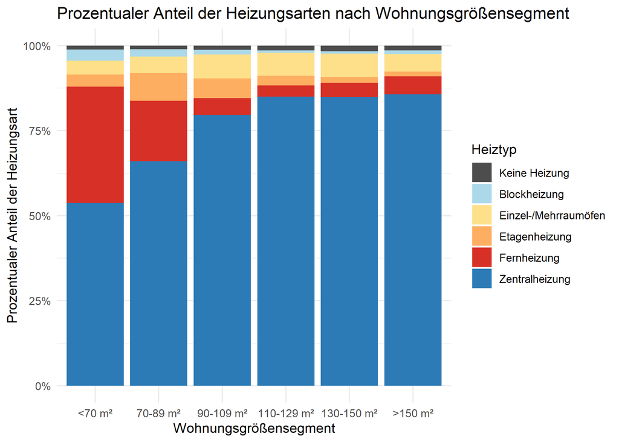

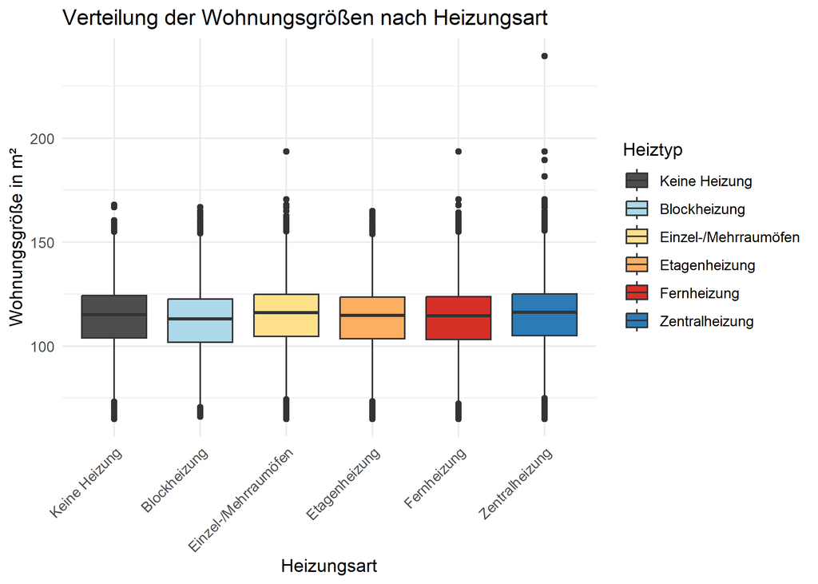

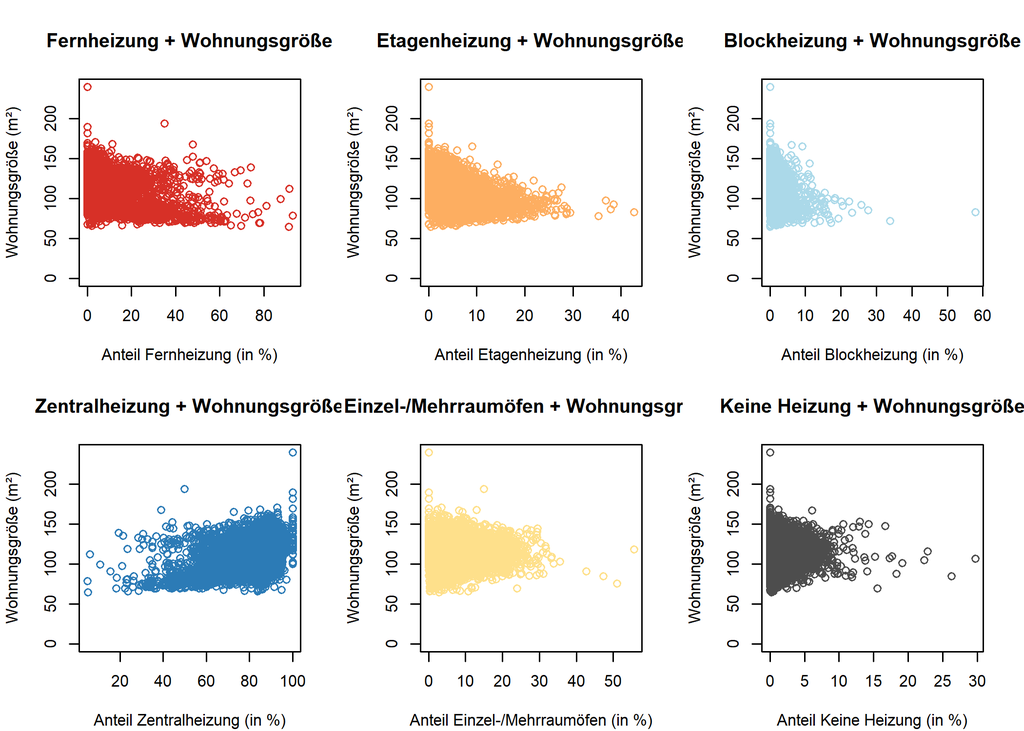

**Verteilung der Heizungsarten nach Mietpreis:**

[figure not shown]

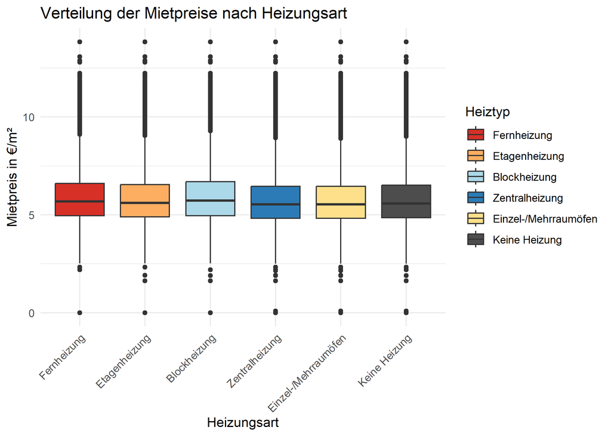

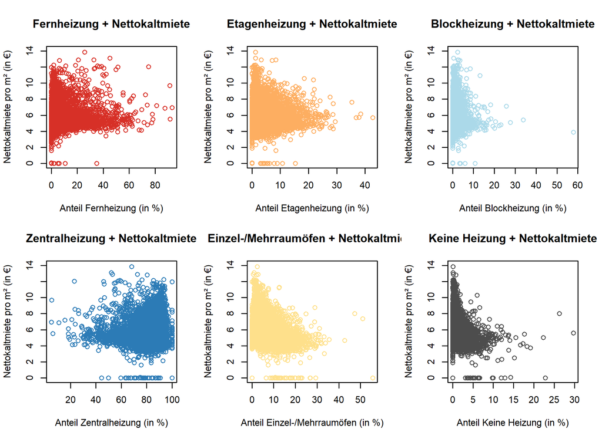

Die Analyse der Heizungsarten zeigt deutlich die Beziehungen zwischen den gewählten Heizsystemen und verschiedenen Wohnungsmerkmalen wie Größe und Mietpreis. Zentralheizungen dominieren in der Nutzung, insbesondere bei größeren Wohnungen. Dies könnte darauf hindeuten, dass große Gebäude oft modern gestaltet sind und einheitliche Heizsysteme bevorzugen, die sich kostengünstig und effizient auf alle Einheiten verteilen lassen. Allerdings fällt auf, dass der prozentuale Anteil an Zentralheizungen mit steigenden Mietpreisen sinkt, was darauf hinweisen könnte, dass diese Systeme in den höchstpreisigen Mietsegmenten weniger häufig vorkommen.

Die Wahl der Heizungsart in Relation zur Wohnungsgröße kann durch infrastrukturelle und wirtschaftliche Überlegungen beeinflusst werden. Größere Immobilienprojekte neigen dazu, Fern- oder Zentralheizungen zu wählen, da diese langfristig wirtschaftlicher und einfacher zu verwalten sind. Baurechtliche Bestimmungen und energetische Auflagen spielen ebenfalls eine entscheidende Rolle bei der Entscheidung über das Heizsystem, insbesondere in Neubauten und bei umfassenden Sanierungen.

Um den Anstieg der Mietpreise trotz Einführung neuer, moderner Heizungssysteme zu dämpfen, könnte die Bundesregierung verschiedene Maßnahmen erwägen. Subventionen oder steuerliche Anreize könnten die Umstellung auf energieeffizientere Heiztechnologien fördern, ohne die Mietpreise zu stark ansteigen zu lassen. Ferner könnten Mietpreisbremsen in bestimmten Regionen praktische Relevanz gewinnen. Die Unterstützung der Vermieter bei der Finanzierung von Renovierungen, sowie dem Übergang zu nachhaltigeren Heizsystemen könnte ebenfalls helfen, die finanziellen Lasten nicht voll auf die Mieter abzuwälzen. Ein weiterer Ansatz wäre die Förderung des Ausbaus von Fernwärmenetzen und der Energieeffizienz in Altbauten, was ältere Wohnungen modernisieren und ineffiziente Heizungssysteme reduzieren würde.

Insgesamt zeigt sich, dass die Wahl der Heizungsart und die Mietpreisdynamik komplexen Wechselwirkungen unterliegen, die von infrastrukturellen, wirtschaftlichen und rechtlichen Rahmenbedingungen beeinflusst werden. Es ist wichtig, strategische Maßnahmen zu ergreifen, um die Balance zwischen effizienten Heizsystemen und bezahlbarem Wohnraum zu wahren, während gleichzeitig der Übergang zu nachhaltigeren, energieeffizienten Wohnlösungen gefördert wird.

*(Quelle: https://oekoloco.de/heizungen/heizungsarten/fernwaerme/)*

Wie Sie in der Aufgabe 15 gesehen haben, haben Ulm und Stuttgart, sowie Dresden und Chemnitz ähnliche Verhältnisse bezüglich der Verteilung der Mietkosten über die Stadt hinweg. Aufgrund dessen beschränken Sie sich bei dieser Aufgabe auf die Städte Stuttgart und Dresden. Hier sollen Sie sich die einzelnen Heizungsarten über die Stadtteile hinweg anschauen, wie sich diese verteilen und ob hier Ähnlichkeiten zur Mietpreissstrukur vorliegt. Weiterhin sind vor allem die Heizungsarten Fernwärme, Zentralheizung und Etagenheizung in viele deutschen Wohnungen größtenteils verbaut, weshalb Sie gerade deswegen diese drei Heiztypen genauer beleuchten und untersuchen sollen.

**19. Deshalb sollten Sie sich in einem ersten Schritt [diese Geogitter-Daten für die verschiedenen Heinzungsarten vom statistischen Bundesamt herunterladen](https://www.zensus2022.de/static/Zensus_Veroeffentlichung/Zensus2022_Heizungsart.zip). Speichern Sie die zip-Datei im Ordner `Daten` ab. Nutzen Sie erneut den Datensatz shape_file aus der Aufgabe 4 und joinen Sie die Informationen zu den Heizungsarten über die Variablen `x_mp_1km` und `y_mp_1km`.**

In ihrem Datensatz können Sie sehen, dass es Einträge mit “-” gibt. Diese sollen sie für alle Heizungstypen durch 0 ersetzen. Achten Sie auch darauf, dass über alle Heizungstypen hinweg die Werte als numeric vorliegen.

Erstellen Sie nun für die Heizungsarten “Fernheizung”, “Etagenheizung” und “Zentralheizung” eine neue Spalte mit dem Anteil des jeweiligen Heizungstyps an allen Heizungen (`Insgesamt_Heizungsart`) je Gemeinde. Schließlich sollen Sie nun für die drei genannten Heizungsarten eine Karte erzeugen, welche den Anteil je Gitterebene im Stadtbezirk darstellt.

Beschreiben und interpretieren Sie ihre Grafiken. Berücksichtigen Sie dabei insbesondere folgende Fragen:

- Wo liegen Besonderheiten oder Muster in beiden Städten?
- Gibt es in Stuttgart und Dresden Stadtteile, bei denen bestimmte Heizungstypen in Einklang mit den Mietpreisen stehen, genauer gesagt, welche Heizungsarten korrelieren mit höheren oder niedrigeren Mietpreisen? Vergleichen Sie dazu die Ergebnisse aus Aufgabe 15.
- Was könnten Gründe sein, dass in bestimmten Stadtteilen vorwiegend eine bestimmte Form der Heizung eingebaut ist?
- Gibt es Unterschiede zwischen Ost- und Westdeutschland?
- Haben die Städte Stuttgart oder Dresden in den letzen Jahren Modernisierungen angestoßen oder Neuerungen umgesetzt und finanziell unterstützt, sodass es dort zu größeren Anpassungen bei der Heizungstechnik kam?

*Hinweis 1:* Sie sollen insgesamt für jede Stadt (Stuttgart und Dresden) drei verschiedene Karten erzeugen.

*Hinweis 2:* Achten Sie auf eine sinnvolle Einteilung und Darstellung in den Karten. Nutzen Sie die Karten aus vorherigen Aufgaben als Hilfestellung.

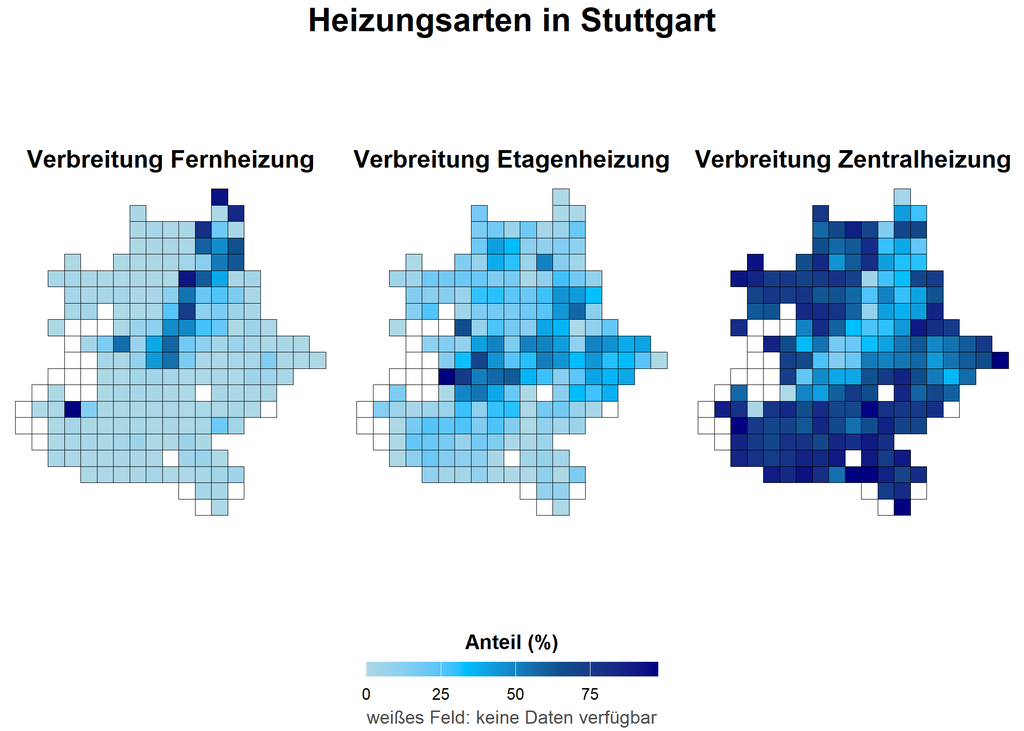

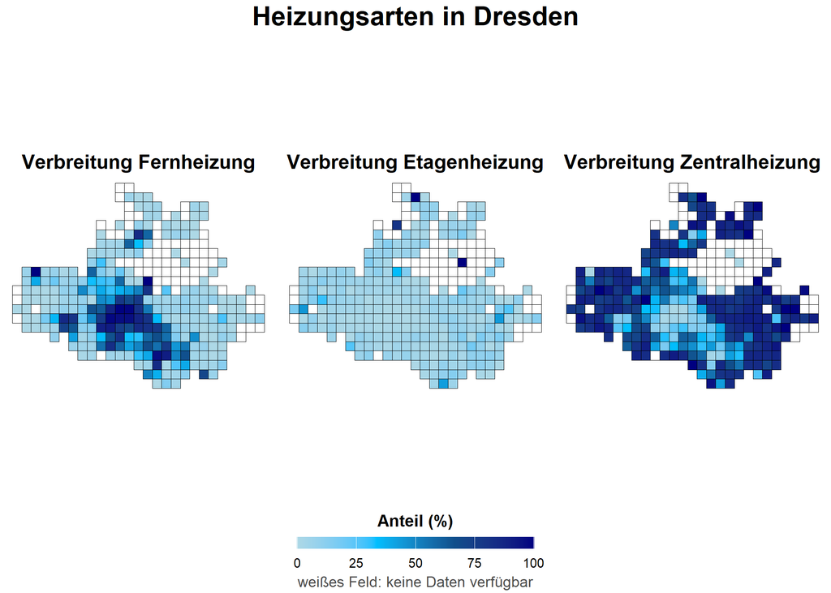

In unserer Untersuchung der Heizungsarten in Stuttgart und Dresden sind gewisse Muster aufgefallen, die durch Stadtentwicklung, Mietpreise, historische Einflüsse und Modernisierungen erklärt werden können.

In Stuttgart sehen wir, dass Zentralheizungen sehr verbreitet sind. Das zeigt, dass in der Stadt viele Modernisierungen durchgeführt wurden, um die Energieeffizienz zu verbessern. Besonders im Nordosten bis ins Zentrum wird oft Fernwärme genutzt, was darauf hindeutet, dass dort neue Wohnanlagen entstanden sind, die von der Effizienz und Umweltfreundlichkeit solcher Systeme profitieren. In älteren Stadtteilen findet man hingegen häufiger Etagenheizungen, die typisch für Altbauten sind und oft aus finanziellen oder baulichen Gründen nicht durch modernere Systeme ersetzt wurden.

In Dresden dominiert ebenfalls die Zentralheizung, aber hier ist die Verteilung etwas anders. Am Stadtrand sind Zentralheizungen besonders häufig, während im zentralen Stadtgebiet viel Fernwärme genutzt wird. Diese Verteilung könnte darauf hindeuten, dass in den zentraleren Lagen Gebäude von modernen und umweltfreundlichen Fernwärmesystemen profitieren. Etagenheizungen sind in Dresden weniger verbreitet, was darauf schließen lässt, dass die Stadt umfassendere Modernisierungen durchlaufen hat, um ältere Systeme effizienter zu gestalten und die Energienutzung zu optimieren.

Die Gründe für die Bevorzugung bestimmter Heizungsarten in bestimmten Stadtteilen können historisch und wirtschaftlich erklärt werden. In älteren Gebäuden hat man oft die ursprünglichen Etagenheizungen beibehalten, da ein Austausch zu aufwendig oder teuer wäre. Außerdem unterstützen politische Maßnahmen und Förderprogramme den Wechsel zu effizienteren Heizsystemen, wie Fernwärme.

Beim Vergleich zwischen Stuttgart und Dresden sieht man Unterschiede, die auf ihre jeweilige städtebauliche und historische Entwicklung zurückzuführen sind. Trotz dieser Unterschiede sind beide Städte aktiv dabei, ihre Heizungssysteme zu modernisieren, was oft durch staatliche Förderungen unterstützt wird. Solche Entwicklungen reflektieren sowohl technologische Fortschritte als auch gesellschaftliche und wirtschaftliche Veränderungen, die das städtische Leben beeinflussen.

*(Quelle:https://www.zeit.de/politik/deutschland/2023-05/heizungsgesetz-ostdeutschland-kritik-waermewende)*

Abschließend sollen Sie die Zusatzaufgabe noch einmal rekapitulieren und einige Fragen dazu beantworten.

**20. Sie sollen sich noch einmal bewusst werden, was Sie in den vorherigen Aufgaben analysiert haben und in welcher Form ihre Ergebnisse anwendbar und verallgemeinbar sind. Beantworten Sie dazu Frage 1 und 2.**

*Frage 1: Betrachten Sie hierzu noch einmal exemplarisch die Städte Stuttgart und Dresden.*

- Sind die Zusammenhänge zwischen Mietpreisen in den Städten und sozioökonomischer Faktoren vor allem auf Unterschiede zwischen den Städten oder auf Unterschiede innerhalb der Stadt zurückzuführen. Bei welchen Faktoren ist dies der Fall, wo nicht?
- Wie kann der Staat im Hinblick auf die unterschiedlichen Heizungsarten in den Städten eingreifen, um Wohnraum preiswerter zu gestalten?

*Frage 2: Schauen Sie sich noch einmal die Verteilung der Heizungsarten (Fern-, Etagen- und Zentralheizungen) für Stuttgart und Dresden in Aufgabe 19 an. Betrachten Sie im Vergleich dazu ihre Grafik aus Aufgabe 8, sowie ihre Tabelle in Aufgabe 13?*

- Was fällt Ihnen hier auf?
- Gibt es bestimmte Heizungstypen, die nur in alten oder neuen Wohnungen vorkommen?
- Welche Schlüsse würden Sie ziehen, die mit Handlungen der Politik einhergehen?
1. Die Zusammenhänge zwischen den Mietpreisen und sozioökonomischen Faktoren in Dresden und Stuttgart lassen sich teils auf Unterschiede zwischen den Städten und teils auf Variationen innerhalb der Städte zurückführen. Unterschiede innerhalb der Städte betreffen vor allem die räumliche Struktur und die Mietpreisverteilung. In Stuttgart konzentrieren sich höhere Mietpreise im Stadtzentrum und in wirtschaftlich attraktiven Vierteln. Dies spiegelt die starke wirtschaftliche Dynamik wider, insbesondere durch die Automobilindustrie, die hohe Nachfrage nach zentralem Wohnraum erzeugt. Dresden hingegen zeigt eine homogenere Mietstruktur, insbesondere in den Randgebieten, was auf eine geringere wirtschaftliche Polarisierung hinweist. Hier dominieren niedrigere Mietpreise, die eng mit den historischen und wirtschaftlichen Gegebenheiten der Region verbunden sind.

   Faktoren wie die Verfügbarkeit von Fernwärme und modernen Heizsystemen variieren sowohl zwischen den Städten als auch innerhalb der Städte. In Stuttgart ist Fernwärme häufiger in Neubaugebieten und zentralen Vierteln anzutreffen, während Etagenheizungen in älteren, weniger modernisierten Bereichen vorherrschen. Dresden hat im Vergleich eine höhere Dichte an zentralisierten Heizsystemen, was auf umfassendere Modernisierungen hindeutet, die insbesondere durch ostdeutsche Förderprogramme nach der Wiedervereinigung unterstützt wurden.

   Um Wohnraum preiswerter zu gestalten, könnte der Staat in mehreren Bereichen eingreifen. Zum einen könnten gezielte Förderprogramme für energetische Sanierungen helfen, ältere Gebäude auf effizientere Heizsysteme umzurüsten, wodurch Betriebskosten gesenkt und Modernisierungen finanziell erleichtert werden. Zum anderen könnte der Ausbau von Fernwärmenetzen gefördert werden, insbesondere in Stadtteilen mit einer hohen Konzentration an Altbauten. Ergänzend wären Maßnahmen zur Begrenzung der Mietpreissteigerungen in begehrten Vierteln und die Förderung von sozialem Wohnungsbau in Städten wie Stuttgart und Dresden sinnvoll.
2. Die Verteilung der Heizungsarten zeigt deutliche Muster, die mit den Baujahrsgruppen und den Mietpreisen korrespondieren. In Stuttgart und Dresden sind Zentralheizungen die vorherrschende Heizungsart, was auf umfangreiche Modernisierungen und den Ausbau effizienter Heizungssysteme hinweist. Fernwärme ist in beiden Städten insbesondere in Neubauten und zentraleren Stadtteilen verbreitet, da solche Systeme mit moderner Infrastruktur verbunden sind. Etagenheizungen hingegen finden sich primär in älteren Gebäuden, vor allem in Stadtteilen mit geringeren Mietpreisen.

   Beim Vergleich der Verteilung der Heizungsarten mit den Baujahrsgruppen fällt auf, dass Etagenheizungen häufig in Gebäuden vorkommen, die vor 1969 erbaut wurden. Diese Heizsysteme wurden oft beibehalten, da sie in Altbauten einfacher zu warten sind und Modernisierungen mit höheren Kosten verbunden wären. Zentralheizungen und Fernwärme dominieren in Neubauten oder modernisierten Gebäuden. Diese Verteilung korrespondiert mit den Mietpreisdaten aus Aufgabe 13, wo höhere Mietpreise in Stadtteilen mit modernisierten Gebäuden und effizienteren Heizsystemen zu finden sind.

   Die Politik könnte aus diesen Beobachtungen wichtige Schlüsse ziehen. Ein verstärkter Fokus auf die Förderung energetischer Modernisierungen, insbesondere in älteren Gebäuden, könnte dazu beitragen, die Abhängigkeit von ineffizienten Heizsystemen wie Etagenheizungen zu verringern. Gleichzeitig sollten Programme zur Unterstützung des Ausbaus von Fernwärme- und Zentralheizungen ausgeweitet werden, um sowohl die Umweltbelastung zu reduzieren als auch den Wohnraum langfristig bezahlbar zu halten. Diese Maßnahmen könnten auch soziale Ungleichheiten verringern, indem sie energieeffiziente und kostengünstige Heizsysteme für eine breitere Bevölkerungsschicht zugänglich machen.